# Rapport : Modèles Linéaires Généralisés & Choix de Modèles

Sophie ROBERT OKADA

2024-06-30

# 1. Introduction

Dans le cadre du projet sur les données météorologiques à Bâle, nous cherchons à prédire s’il pleuvra le lendemain à partir de mesures journalières recueillies entre 2010 et 2018. La variable à prédire “pluie.demain” $Y_i$ est de type binaire où $Y_i \in \{0, 1\}$, et les variables explicatives comprennent des données de température, d’humidité, de pression, de nébulosité, de vitesse et direction des vents, de précipitations et d’ensoleillement.

Pour prédire correctement notre variable d’intérêt, nous appliquerons un modèle linéaire généralisé particulièrement adapté pour gérer une réponse binaire. Un modèle linéaire généralisé est défini par le choix de la famille de lois aléatoires $L$ et par la fonction de lien $g$, où $g(E[Y_i]) = \beta_0 + \beta_1x_i$. Pour la variable dépendante $Y_i$, représentant la pluie le lendemain, nous appliquerons deux approches principales : la régression logistique dans un premier temps, suivi d’un modèle de régression probit dans une deuxième temps, afin de comparer leurs efficacités et précisions dans la prédiction des jours de pluie survenant le lendemain.

## 1.1 Chargement des packages utiles

Pour réaliser l’analyse, nous commencerons tout d’abord par charger les packages utiles suivants:

```r
rm(list = ls())
invisible(suppressMessages(lapply(c("readr", "corrplot", "forecast",
    "car", "stats", "ggplot2", "kableExtra", "tidyverse", "gridExtra",
    "grid", "dplyr", "viridis", "summarytools", "reshape2", "knitr",
    "MASS", "ROCR"), library, character.only = TRUE)))
```

## 1.2 Chargement & Visualisation des données

Nous allons ensuite charger les données d’entraînement “meteo.train”, puis nous allons exclure la première variable nommée X qui est juste l’indice du nombre de données.

```r
meteo_train <- read_csv("C:/Documents/Dauphine/Module 2/Modèle Linéaire Généralisé/Projet/meteo.train.csv",
    show_col_types = FALSE, name_repair = "minimal")
meteo_train <- meteo_train[, -1]
```

Comme les noms des variables semblent difficiles à lire, et pour obtenir plus de clarté dans notre analyse, nous commencerons par renommer les variables. Les variables renommées sont présentées dans le tableau ci-dessous.

```r
meteo_train <- meteo_train %>%
    rename(Year = Year, Month = Month, Day = Day, Hour = Hour,
        Minute = Minute, TempMean = Temperature.daily.mean..2.m.above.gnd.,
        HumidityMean = Relative.Humidity.daily.mean..2.m.above.gnd.,
        PressureMean = Mean.Sea.Level.Pressure.daily.mean..MSL.,
        PrecipitationTotal = Total.Precipitation.daily.sum..sfc.,
        Snowfall = Snowfall.amount.raw.daily.sum..sfc., TotalCloudMean = Total.Cloud.Cover.daily.mean..sfc.,
        HighCloudMean = High.Cloud.Cover.daily.mean..high.cld.lay.,
        MediumCloudMean = Medium.Cloud.Cover.daily.mean..mid.cld.lay.,
        LowCloudMean = Low.Cloud.Cover.daily.mean..low.cld.lay.,
        Sunshine = Sunshine.Duration.daily.sum..sfc., RadShortwave = Shortwave.Radiation.daily.sum..sfc.,
        WindSpeed10mMean = Wind.Speed.daily.mean..10.m.above.gnd.,
        WindDir10mMean = Wind.Direction.daily.mean..10.m.above.gnd.,
        WindSpeed80mMean = Wind.Speed.daily.mean..80.m.above.gnd.,
        WindDir80mMean = Wind.Direction.daily.mean..80.m.above.gnd.,
        WindSpeed900mbMean = Wind.Speed.daily.mean..900.mb.,
        WindDir900mbMean = Wind.Direction.daily.mean..900.mb.,
        WindGustMean = Wind.Gust.daily.mean..sfc., TempMax = Temperature.daily.max..2.m.above.gnd.,
        TempMin = Temperature.daily.min..2.m.above.gnd., HumidityMax = Relative.Humidity.daily.max..2.m.above.gnd.,
        HumidityMin = Relative.Humidity.daily.min..2.m.above.gnd.,
        PressureMax = Mean.Sea.Level.Pressure.daily.max..MSL.,
        PressureMin = Mean.Sea.Level.Pressure.daily.min..MSL.,
        TotalCloudMax = Total.Cloud.Cover.daily.max..sfc., TotalCloudMin = Total.Cloud.Cover.daily.min..sfc.,
        HighCloudMax = High.Cloud.Cover.daily.max..high.cld.lay.,
        HighCloudMin = High.Cloud.Cover.daily.min..high.cld.lay.,
        MediumCloudMax = Medium.Cloud.Cover.daily.max..mid.cld.lay.,
        MediumCloudMin = Medium.Cloud.Cover.daily.min..mid.cld.lay.,
        LowCloudMax = Low.Cloud.Cover.daily.max..low.cld.lay.,
        LowCloudMin = Low.Cloud.Cover.daily.min..low.cld.lay.,
        WindSpeed10mMax = Wind.Speed.daily.max..10.m.above.gnd.,
        WindSpeed10mMin = Wind.Speed.daily.min..10.m.above.gnd.,
        WindSpeed80mMax = Wind.Speed.daily.max..80.m.above.gnd.,
        WindSpeed80mMin = Wind.Speed.daily.min..80.m.above.gnd.,
        WindSpeed900mbMax = Wind.Speed.daily.max..900.mb., WindSpeed900mbMin = Wind.Speed.daily.min..900.mb.,
        WindGustMax = Wind.Gust.daily.max..sfc., WindGustMin = Wind.Gust.daily.min..sfc.,
        pluie.demain = pluie.demain)

old_names <- c("Year", "Month", "Day", "Hour", "Minute", "Temperature.daily.mean..2.m.above.gnd.",
    "Relative.Humidity.daily.mean..2.m.above.gnd.", "Mean.Sea.Level.Pressure.daily.mean..MSL.",
    "Total.Precipitation.daily.sum..sfc.", "Snowfall.amount.raw.daily.sum..sfc.",
    "Total.Cloud.Cover.daily.mean..sfc.", "High.Cloud.Cover.daily.mean..high.cld.lay.",
    "Medium.Cloud.Cover.daily.mean..mid.cld.lay.", "Low.Cloud.Cover.daily.mean..low.cld.lay.",
    "Sunshine.Duration.daily.sum..sfc.", "Shortwave.Radiation.daily.sum..sfc.",
    "Wind.Speed.daily.mean..10.m.above.gnd.", "Wind.Direction.daily.mean..10.m.above.gnd.",
    "Wind.Speed.daily.mean..80.m.above.gnd.", "Wind.Direction.daily.mean..80.m.above.gnd.",
    "Wind.Speed.daily.mean..900.mb.", "Wind.Direction.daily.mean..900.mb.",
    "Wind.Gust.daily.mean..sfc.", "Temperature.daily.max..2.m.above.gnd.",
    "Temperature.daily.min..2.m.above.gnd.", "Relative.Humidity.daily.max..2.m.above.gnd.",
    "Relative.Humidity.daily.min..2.m.above.gnd.", "Mean.Sea.Level.Pressure.daily.max..MSL.",
    "Mean.Sea.Level.Pressure.daily.min..MSL.", "Total.Cloud.Cover.daily.max..sfc.",
    "Total.Cloud.Cover.daily.min..sfc.", "High.Cloud.Cover.daily.max..high.cld.lay.",
    "High.Cloud.Cover.daily.min..high.cld.lay.", "Medium.Cloud.Cover.daily.max..mid.cld.lay.",
    "Medium.Cloud.Cover.daily.min..mid.cld.lay.", "Low.Cloud.Cover.daily.max..low.cld.lay.",
    "Low.Cloud.Cover.daily.min..low.cld.lay.", "Wind.Speed.daily.max..10.m.above.gnd.",
    "Wind.Speed.daily.min..10.m.above.gnd.", "Wind.Speed.daily.max..80.m.above.gnd.",
    "Wind.Speed.daily.min..80.m.above.gnd.", "Wind.Speed.daily.max..900.mb.",
    "Wind.Speed.daily.min..900.mb.", "Wind.Gust.daily.max..sfc.",
    "Wind.Gust.daily.min..sfc.", "pluie.demain")
new_names <- c("Year", "Month", "Day", "Hour", "Minute", "TempMean",
    "HumidityMean", "PressureMean", "PrecipitationTotal", "Snowfall",
    "TotalCloudMean", "HighCloudMean", "MediumCloudMean", "LowCloudMean",
    "Sunshine", "RadShortwave", "WindSpeed10mMean", "WindDir10mMean",
    "WindSpeed80mMean", "WindDir80mMean", "WindSpeed900mbMean",
    "WindDir900mbMean", "WindGustMean", "TempMax", "TempMin",
    "HumidityMax", "HumidityMin", "PressureMax", "PressureMin",
    "TotalCloudMax", "TotalCloudMin", "HighCloudMax", "HighCloudMin",
    "MediumCloudMax", "MediumCloudMin", "LowCloudMax", "LowCloudMin",
    "WindSpeed10mMax", "WindSpeed10mMin", "WindSpeed80mMax",
    "WindSpeed80mMin", "WindSpeed900mbMax", "WindSpeed900mbMin",
    "WindGustMax", "WindGustMin", "pluie.demain")
renamed_columns <- data.frame(NewNames = new_names, OldNames = old_names)
kable(renamed_columns, caption = "Nouveaux Noms de variables meteo_train")
```

Nouveaux Noms de variables meteo_train

| NewNames | OldNames |
| --- | --- |
| Year | Year |
| Month | Month |
| Day | Day |
| Hour | Hour |
| Minute | Minute |
| TempMean | Temperature.daily.mean..2.m.above.gnd. |
| HumidityMean | Relative.Humidity.daily.mean..2.m.above.gnd. |
| PressureMean | Mean.Sea.Level.Pressure.daily.mean..MSL. |
| PrecipitationTotal | Total.Precipitation.daily.sum..sfc. |
| Snowfall | Snowfall.amount.raw.daily.sum..sfc. |
| TotalCloudMean | Total.Cloud.Cover.daily.mean..sfc. |
| HighCloudMean | High.Cloud.Cover.daily.mean..high.cld.lay. |
| MediumCloudMean | Medium.Cloud.Cover.daily.mean..mid.cld.lay. |
| LowCloudMean | Low.Cloud.Cover.daily.mean..low.cld.lay. |
| Sunshine | Sunshine.Duration.daily.sum..sfc. |
| RadShortwave | Shortwave.Radiation.daily.sum..sfc. |
| WindSpeed10mMean | Wind.Speed.daily.mean..10.m.above.gnd. |
| WindDir10mMean | Wind.Direction.daily.mean..10.m.above.gnd. |
| WindSpeed80mMean | Wind.Speed.daily.mean..80.m.above.gnd. |
| WindDir80mMean | Wind.Direction.daily.mean..80.m.above.gnd. |
| WindSpeed900mbMean | Wind.Speed.daily.mean..900.mb. |
| WindDir900mbMean | Wind.Direction.daily.mean..900.mb. |
| WindGustMean | Wind.Gust.daily.mean..sfc. |
| TempMax | Temperature.daily.max..2.m.above.gnd. |
| TempMin | Temperature.daily.min..2.m.above.gnd. |
| HumidityMax | Relative.Humidity.daily.max..2.m.above.gnd. |
| HumidityMin | Relative.Humidity.daily.min..2.m.above.gnd. |
| PressureMax | Mean.Sea.Level.Pressure.daily.max..MSL. |
| PressureMin | Mean.Sea.Level.Pressure.daily.min..MSL. |
| TotalCloudMax | Total.Cloud.Cover.daily.max..sfc. |
| TotalCloudMin | Total.Cloud.Cover.daily.min..sfc. |
| HighCloudMax | High.Cloud.Cover.daily.max..high.cld.lay. |
| HighCloudMin | High.Cloud.Cover.daily.min..high.cld.lay. |
| MediumCloudMax | Medium.Cloud.Cover.daily.max..mid.cld.lay. |
| MediumCloudMin | Medium.Cloud.Cover.daily.min..mid.cld.lay. |
| LowCloudMax | Low.Cloud.Cover.daily.max..low.cld.lay. |
| LowCloudMin | Low.Cloud.Cover.daily.min..low.cld.lay. |
| WindSpeed10mMax | Wind.Speed.daily.max..10.m.above.gnd. |
| WindSpeed10mMin | Wind.Speed.daily.min..10.m.above.gnd. |
| WindSpeed80mMax | Wind.Speed.daily.max..80.m.above.gnd. |
| WindSpeed80mMin | Wind.Speed.daily.min..80.m.above.gnd. |
| WindSpeed900mbMax | Wind.Speed.daily.max..900.mb. |
| WindSpeed900mbMin | Wind.Speed.daily.min..900.mb. |
| WindGustMax | Wind.Gust.daily.max..sfc. |
| WindGustMin | Wind.Gust.daily.min..sfc. |
| pluie.demain | pluie.demain |

Dans le summary des données présenté en annexe 1 de ce report, *Summary des données*, et dans le rapport html, nous remarquons qu’il y a 1180 lignes et pas de valeurs manquantes. Les variables “Hour” et “Minute” étant semblables pour toutes les données, nous exclurons ces variables.

```r
if (knitr::is_html_output()) {
    s = dfSummary(meteo_train)
    print(s, method = "render", headings = FALSE)
}
```

| **No** | **Variable** | **Stats / Values** | **Freqs (% of Valid)** | **Graph** | **Valid** | **Missing** |
| --- | --- | --- | --- | --- | --- | --- |
| 1 | Year [numeric] | Mean (sd) : 2013.9 (2.4) min ≤ med ≤ max: 2010 ≤ 2014 ≤ 2018 IQR (CV) : 4 (0) | 2010 : 86 ( 7.3% ) 2011 : 153 ( 13.0% ) 2012 : 149 ( 12.6% ) 2013 : 144 ( 12.2% ) 2014 : 147 ( 12.5% ) 2015 : 143 ( 12.1% ) 2016 : 143 ( 12.1% ) 2017 : 143 ( 12.1% ) 2018 : 72 ( 6.1% ) |  | 1180 (100.0%) | 0 (0.0%) |
| 2 | Month [numeric] | Mean (sd) : 6.4 (3.4) min ≤ med ≤ max: 1 ≤ 6 ≤ 12 IQR (CV) : 6 (0.5) | 12 distinct values |  | 1180 (100.0%) | 0 (0.0%) |
| 3 | Day [numeric] | Mean (sd) : 15.8 (8.8) min ≤ med ≤ max: 1 ≤ 16 ≤ 31 IQR (CV) : 15 (0.6) | 31 distinct values |  | 1180 (100.0%) | 0 (0.0%) |
| 4 | Hour [numeric] | 1 distinct value | 0 : 1180 ( 100.0% ) |  | 1180 (100.0%) | 0 (0.0%) |
| 5 | Minute [numeric] | 1 distinct value | 0 : 1180 ( 100.0% ) |  | 1180 (100.0%) | 0 (0.0%) |
| 6 | TempMean [numeric] | Mean (sd) : 12.2 (7) min ≤ med ≤ max: -7.6 ≤ 12.1 ≤ 29.4 IQR (CV) : 10.8 (0.6) | 961 distinct values |  | 1180 (100.0%) | 0 (0.0%) |
| 7 | HumidityMean [numeric] | Mean (sd) : 71.4 (9.5) min ≤ med ≤ max: 38.3 ≤ 72.2 ≤ 95.5 IQR (CV) : 13.8 (0.1) | 646 distinct values |  | 1180 (100.0%) | 0 (0.0%) |
| 8 | PressureMean [numeric] | Mean (sd) : 1017 (7.9) min ≤ med ≤ max: 978.9 ≤ 1017 ≤ 1042.4 IQR (CV) : 9.6 (0) | 967 distinct values |  | 1180 (100.0%) | 0 (0.0%) |
| 9 | PrecipitationTotal [numeric] | Mean (sd) : 2.1 (4.1) min ≤ med ≤ max: 0 ≤ 0.1 ≤ 31.5 IQR (CV) : 2.3 (1.9) | 148 distinct values |  | 1180 (100.0%) | 0 (0.0%) |
| 10 | Snowfall [numeric] | Mean (sd) : 0 (0.4) min ≤ med ≤ max: 0 ≤ 0 ≤ 8.6 IQR (CV) : 0 (8) | 27 distinct values |  | 1180 (100.0%) | 0 (0.0%) |
| 11 | TotalCloudMean [numeric] | Mean (sd) : 50.8 (31.7) min ≤ med ≤ max: 0 ≤ 51.7 ≤ 100 IQR (CV) : 54.7 (0.6) | 1007 distinct values |  | 1180 (100.0%) | 0 (0.0%) |
| 12 | HighCloudMean [numeric] | Mean (sd) : 20.3 (21.8) min ≤ med ≤ max: 0 ≤ 11.9 ≤ 100 IQR (CV) : 31.6 (1.1) | 690 distinct values |  | 1180 (100.0%) | 0 (0.0%) |
| 13 | MediumCloudMean [numeric] | Mean (sd) : 31.5 (29.8) min ≤ med ≤ max: 0 ≤ 25 ≤ 100 IQR (CV) : 52.4 (0.9) | 746 distinct values |  | 1180 (100.0%) | 0 (0.0%) |
| 14 | LowCloudMean [numeric] | Mean (sd) : 39.3 (31.1) min ≤ med ≤ max: 0 ≤ 36.4 ≤ 100 IQR (CV) : 56.3 (0.8) | 811 distinct values |  | 1180 (100.0%) | 0 (0.0%) |
| 15 | Sunshine [numeric] | Mean (sd) : 373.1 (275.1) min ≤ med ≤ max: 0 ≤ 366.8 ≤ 1015.8 IQR (CV) : 473.5 (0.7) | 1022 distinct values |  | 1180 (100.0%) | 0 (0.0%) |
| 16 | RadShortwave [numeric] | Mean (sd) : 3984.6 (2153.1) min ≤ med ≤ max: 265.2 ≤ 3675.3 ≤ 8363.3 IQR (CV) : 3627.4 (0.5) | 1093 distinct values |  | 1180 (100.0%) | 0 (0.0%) |
| 17 | WindSpeed10mMean [numeric] | Mean (sd) : 10.7 (6.1) min ≤ med ≤ max: 1.3 ≤ 9.2 ≤ 42.2 IQR (CV) : 6.6 (0.6) | 829 distinct values |  | 1180 (100.0%) | 0 (0.0%) |
| 18 | WindDir10mMean [numeric] | Mean (sd) : 201.8 (61.6) min ≤ med ≤ max: 11.2 ≤ 206.4 ≤ 331.7 IQR (CV) : 101.8 (0.3) | 1139 distinct values |  | 1180 (100.0%) | 0 (0.0%) |
| 19 | WindSpeed80mMean [numeric] | Mean (sd) : 14.3 (7.9) min ≤ med ≤ max: 1.3 ≤ 12.4 ≤ 54 IQR (CV) : 8.9 (0.6) | 930 distinct values |  | 1180 (100.0%) | 0 (0.0%) |
| 20 | WindDir80mMean [numeric] | Mean (sd) : 206.2 (62.3) min ≤ med ≤ max: 12.2 ≤ 213.8 ≤ 333.4 IQR (CV) : 101.6 (0.3) | 1151 distinct values |  | 1180 (100.0%) | 0 (0.0%) |
| 21 | WindSpeed900mbMean [numeric] | Mean (sd) : 24.6 (16) min ≤ med ≤ max: 2.2 ≤ 19.6 ≤ 97.1 IQR (CV) : 19.1 (0.7) | 1041 distinct values |  | 1180 (100.0%) | 0 (0.0%) |
| 22 | WindDir900mbMean [numeric] | Mean (sd) : 206.2 (74.5) min ≤ med ≤ max: 17.4 ≤ 233.5 ≤ 344.8 IQR (CV) : 121.9 (0.4) | 1144 distinct values |  | 1180 (100.0%) | 0 (0.0%) |
| 23 | WindGustMean [numeric] | Mean (sd) : 16.7 (10.3) min ≤ med ≤ max: 2.2 ≤ 14.1 ≤ 79.4 IQR (CV) : 11.7 (0.6) | 929 distinct values |  | 1180 (100.0%) | 0 (0.0%) |
| 24 | TempMax [numeric] | Mean (sd) : 16.5 (7.7) min ≤ med ≤ max: -3.8 ≤ 16.5 ≤ 35.8 IQR (CV) : 11.8 (0.5) | 961 distinct values |  | 1180 (100.0%) | 0 (0.0%) |
| 25 | TempMin [numeric] | Mean (sd) : 8.1 (6.3) min ≤ med ≤ max: -12.5 ≤ 8 ≤ 23.9 IQR (CV) : 9.7 (0.8) | 927 distinct values |  | 1180 (100.0%) | 0 (0.0%) |
| 26 | HumidityMax [numeric] | Mean (sd) : 87.7 (7.6) min ≤ med ≤ max: 59 ≤ 89 ≤ 100 IQR (CV) : 11 (0.1) | 41 distinct values |  | 1180 (100.0%) | 0 (0.0%) |
| 27 | HumidityMin [numeric] | Mean (sd) : 54 (12.5) min ≤ med ≤ max: 19 ≤ 54 ≤ 92 IQR (CV) : 18 (0.2) | 66 distinct values |  | 1180 (100.0%) | 0 (0.0%) |
| 28 | PressureMax [numeric] | Mean (sd) : 1019.9 (7.6) min ≤ med ≤ max: 981.9 ≤ 1019.5 ≤ 1045.4 IQR (CV) : 9.3 (0) | 320 distinct values |  | 1180 (100.0%) | 0 (0.0%) |
| 29 | PressureMin [numeric] | Mean (sd) : 1014.2 (8.5) min ≤ med ≤ max: 977 ≤ 1014.6 ≤ 1038.6 IQR (CV) : 10.2 (0) | 352 distinct values |  | 1180 (100.0%) | 0 (0.0%) |
| 30 | TotalCloudMax [numeric] | Mean (sd) : 88.2 (29.5) min ≤ med ≤ max: 0 ≤ 100 ≤ 100 IQR (CV) : 0 (0.3) | 79 distinct values |  | 1180 (100.0%) | 0 (0.0%) |
| 31 | TotalCloudMin [numeric] | Mean (sd) : 8.7 (23) min ≤ med ≤ max: 0 ≤ 0 ≤ 100 IQR (CV) : 2.4 (2.6) | 107 distinct values |  | 1180 (100.0%) | 0 (0.0%) |
| 32 | HighCloudMax [numeric] | Mean (sd) : 60.2 (43) min ≤ med ≤ max: 0 ≤ 97 ≤ 100 IQR (CV) : 85 (0.7) | 91 distinct values |  | 1180 (100.0%) | 0 (0.0%) |
| 33 | HighCloudMin [numeric] | Mean (sd) : 0.9 (5.1) min ≤ med ≤ max: 0 ≤ 0 ≤ 100 IQR (CV) : 0 (5.4) | 28 distinct values |  | 1180 (100.0%) | 0 (0.0%) |
| 34 | MediumCloudMax [numeric] | Mean (sd) : 70.9 (42.6) min ≤ med ≤ max: 0 ≤ 100 ≤ 100 IQR (CV) : 77.2 (0.6) | 76 distinct values |  | 1180 (100.0%) | 0 (0.0%) |
| 35 | MediumCloudMin [numeric] | Mean (sd) : 2.1 (11.3) min ≤ med ≤ max: 0 ≤ 0 ≤ 100 IQR (CV) : 0 (5.4) | 42 distinct values |  | 1180 (100.0%) | 0 (0.0%) |
| 36 | LowCloudMax [numeric] | Mean (sd) : 80 (38.4) min ≤ med ≤ max: 0 ≤ 100 ≤ 100 IQR (CV) : 0 (0.5) | 47 distinct values |  | 1180 (100.0%) | 0 (0.0%) |
| 37 | LowCloudMin [numeric] | Mean (sd) : 3.9 (16.8) min ≤ med ≤ max: 0 ≤ 0 ≤ 100 IQR (CV) : 0 (4.3) | 46 distinct values |  | 1180 (100.0%) | 0 (0.0%) |
| 38 | WindSpeed10mMax [numeric] | Mean (sd) : 19.1 (9.4) min ≤ med ≤ max: 2.5 ≤ 17.4 ≤ 80 IQR (CV) : 11.1 (0.5) | 773 distinct values |  | 1180 (100.0%) | 0 (0.0%) |
| 39 | WindSpeed10mMin [numeric] | Mean (sd) : 3.6 (3.8) min ≤ med ≤ max: 0 ≤ 2.4 ≤ 27.7 IQR (CV) : 3.3 (1.1) | 247 distinct values |  | 1180 (100.0%) | 0 (0.0%) |
| 40 | WindSpeed80mMax [numeric] | Mean (sd) : 25.4 (10.9) min ≤ med ≤ max: 4 ≤ 23.9 ≤ 93.8 IQR (CV) : 11.6 (0.4) | 889 distinct values |  | 1180 (100.0%) | 0 (0.0%) |
| 41 | WindSpeed80mMin [numeric] | Mean (sd) : 4.7 (5.7) min ≤ med ≤ max: 0 ≤ 2.6 ≤ 37.7 IQR (CV) : 4.7 (1.2) | 316 distinct values |  | 1180 (100.0%) | 0 (0.0%) |
| 42 | WindSpeed900mbMax [numeric] | Mean (sd) : 41.8 (22.5) min ≤ med ≤ max: 4 ≤ 37.1 ≤ 136.2 IQR (CV) : 29.8 (0.5) | 1021 distinct values |  | 1180 (100.0%) | 0 (0.0%) |
| 43 | WindSpeed900mbMin [numeric] | Mean (sd) : 11.1 (11.9) min ≤ med ≤ max: 0 ≤ 6.7 ≤ 76.1 IQR (CV) : 12.3 (1.1) | 565 distinct values |  | 1180 (100.0%) | 0 (0.0%) |
| 44 | WindGustMax [numeric] | Mean (sd) : 29.3 (14.9) min ≤ med ≤ max: 4.3 ≤ 26.1 ≤ 95 IQR (CV) : 18 (0.5) | 185 distinct values |  | 1180 (100.0%) | 0 (0.0%) |
| 45 | WindGustMin [numeric] | Mean (sd) : 6.5 (7.1) min ≤ med ≤ max: 0 ≤ 4 ≤ 58 IQR (CV) : 6.1 (1.1) | 96 distinct values |  | 1180 (100.0%) | 0 (0.0%) |
| 46 | pluie.demain [logical] | 1. FALSE 2. TRUE | 579 ( 49.1% ) 601 ( 50.9% ) |  | 1180 (100.0%) | 0 (0.0%) |

Generated by summarytools 1.0.1 ([R](https://www.r-project.org/) version 4.3.2)  
2024-07-01

# 2. Représentation Graphique et Corrélation

## 2.1 Représentation Graphique - BoxPlots

Nous allons regarder maintenant les différentes variables numériques par rapport à la variable binaire “pluie.demain” à l’aide de box plots.

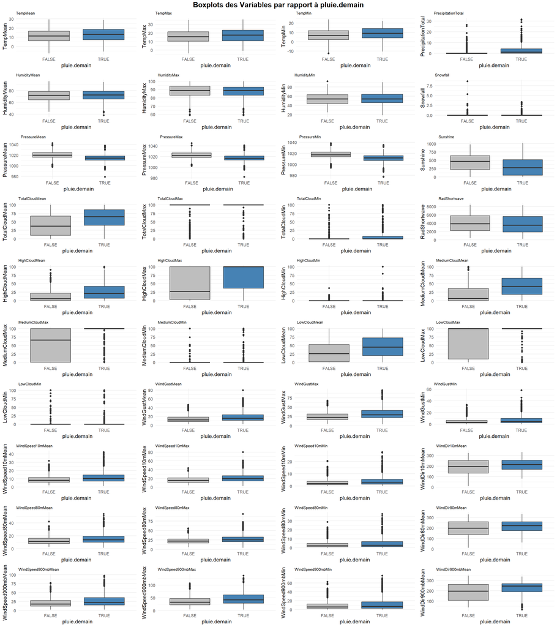

```r
variables <- c("TempMean", "TempMax", "TempMin", "PrecipitationTotal",
    "HumidityMean", "HumidityMax", "HumidityMin", "Snowfall",
    "PressureMean", "PressureMax", "PressureMin", "Sunshine",
    "TotalCloudMean", "TotalCloudMax", "TotalCloudMin", "RadShortwave",
    "HighCloudMean", "HighCloudMax", "HighCloudMin", "MediumCloudMean",
    "MediumCloudMax", "MediumCloudMin", "LowCloudMean", "LowCloudMax",
    "LowCloudMin", "WindGustMean", "WindGustMax", "WindGustMin",
    "WindSpeed10mMean", "WindSpeed10mMax", "WindSpeed10mMin",
    "WindDir10mMean", "WindSpeed80mMean", "WindSpeed80mMax",
    "WindSpeed80mMin", "WindDir80mMean", "WindSpeed900mbMean",
    "WindSpeed900mbMax", "WindSpeed900mbMin", "WindDir900mbMean")

plot_list <- list()
for (var in variables) {
    Bplot <- ggplot(meteo_train, aes_string(x = "pluie.demain",
        y = var, fill = "pluie.demain")) + geom_boxplot() + scale_fill_manual(values = c(`TRUE` = "steelblue",
        `FALSE` = "grey")) + labs(title = var, x = "pluie.demain",
        y = var) + theme_minimal() + theme(legend.position = "none",
        plot.title = element_text(size = 8))
    plot_list[[var]] <- Bplot
}

title <- textGrob("Boxplots des Variables par rapport à pluie.demain",
    gp = gpar(fontsize = 15, fontface = "bold"))

grid.arrange(arrangeGrob(grobs = plot_list, ncol = 4), top = title)
```

Sur les box-plots précédents, on notera pour les variables suivantes de:

- Températures (TempMean, TempMax & TempMin) que les médianes semblent très légèrement plus élevées les jours de pluie comparés aux jours sans pluie bien que les différences ne soient pas très marquées. Les variables “température” semblent être des prédicteurs très moyens de la pluie du lendemain.
- Précipitations (PrecipitationTolal & Snowfall) que la présence de pluie est légèrement plus élévée les jours de pluie le lendemain. La variable Snowfall ne semble pas être un bon prédicteur car la plupart des valeurs sont à zéros dans les deux catégories.
- Humidité (HumidityMean, HumidityMax & HumidityMin) que l’humidité moyenne et minimale sont légèrement plus élevées les jours de pluie le lendemain et peuvent être des bons prédicteurs. La variable HumidityMax semble être un moins bon indicateur des conditions de pluie car la médiane est similaire entre les jours avec et sans pluie et les valeurs maximales sont plus élevées les jours sans pluie.
- Pression (PressureMean, PressureMax & PressureMin) que les valeurs sont plus faibles les jours de pluie, indiquant des conditions de pression favorisant la pluie.
- Ensoleillement (Sunshine) qu’il y a une réduction des minutes d’ensoleillement les jours de pluie.
- Nébulosité (TotalCloudMean, TotalCloudMax, TotalCloudMin, HighCloudMean, HighCloudMax, HighCloudMin, MediumCloudMean, MediumCloudMax, MediumCloudMin, LowCloudMean, LowCloudMax, LowCloudMin) que les variables se terminant par “Mean” et “Max” montrent une nébulosité plus élévée les jours de pluie le lendemain et semblent être de bons prédicteurs. Les variables se terminant par “Min”, quant à elles, montrent beaucoup moins différences significatives entre les jours avec et sans pluie et seront moins utiles à la prédictions
- Rayonnement solaire (RadShortwave) que la variable est légèrement réduite les jours de pluie ce qui peut s’expliquer par une couverture nuageuse plus épaisse. Cette variable peut être un bon prédicteur.
- Rafales de Vent (WindGustMean, WindGustMax, WindGustMin) qu’il y a des différences notables entre les jours sans et avec pluie. Les valeurs semblent plus élevées les jours de pluie indiquant des conditions de vent plus fort.
- Vitesse et direction du vent (WindSpeed10mMean, WindSpeed10mMax, WindSpeed10mMin, WindDir10mMean, WindSpeed80mMean, WindSpeed80mMax, WindSpeed80mMin, WindDir80mMean, WindSpeed900mbMean, WindSpeed900mbMax, WindSpeed900mbMin, WindDir900mbMean,) que ces variables semblent être de bons prédicteurs de pluie le lendemain car elles semblent toutes plus élevées les jours de pluie le lendemain.

Pour nous assurer de ces résultats, nous allons voir maintenant les corrélations entre les variables.

## 2.2 Corrélations entre les variables

### 2.2.1 Matrice de Corrélation

La matrice de corrélation présentée ci-dessous permet de visualiser les corrélations entre les différentes variables ainsi que leur corrélation avec le variable pluie.demain = “TRUE”.

On observe ici que les variables comportant “Mean”, “Max” & “Min” sont fortement corrélées entre elles. Pour éviter les problèmes de colinéarité, il sera nécessaire de sélectionner parmi ces 3 types de variables celle qui présente la plus forte corrélation avec la variable “pluie.demain”. On pourra donc ainsi inclure la variable la plus pertinente dans notre modèle.

On remarque également des fortes corrélations entre les variables de pression et de nébulosité totale indiquant que les pressions plus basses sont souvent associés à une couverture nuageuse plus élévée.

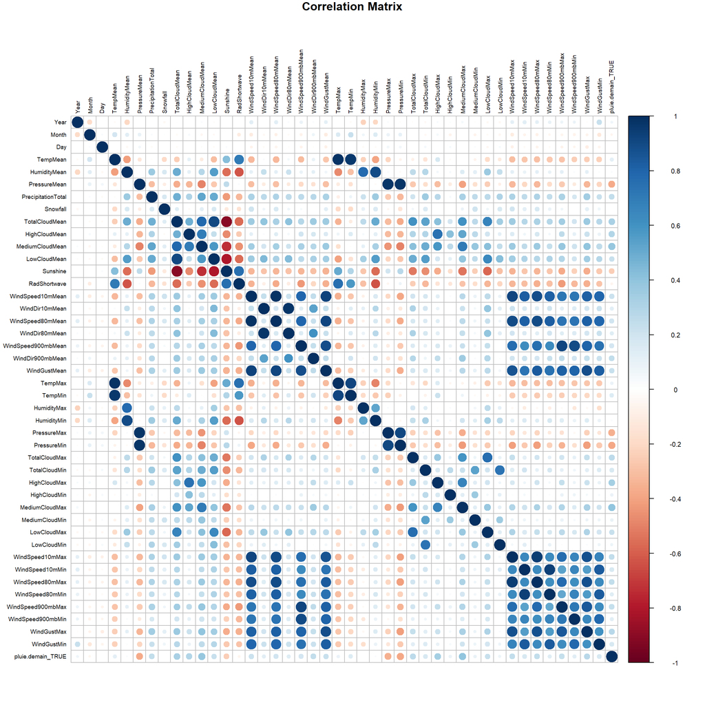

```r
# Exclusion des variables 'Hour' et 'Minute' de meteo_train
meteo_train <- meteo_train %>%
    dplyr::select(-Hour, -Minute)
pluie.demain_TRUE <- meteo_train$pluie.demain == "TRUE"
columns_excluded <- c("pluie.demain")
data_for_corr <- meteo_train[, !(names(meteo_train) %in% columns_excluded)]
data_for_corr <- cbind(data_for_corr, pluie.demain_TRUE)
cor_matrix <- cor(data_for_corr, use = "complete.obs")
# Matrice de corrélation
corrplot(cor_matrix, method = "circle", type = "full", tl.col = "black",
    tl.srt = 90, cl.cex = 0.7, tl.cex = 0.6, mar = c(0, 0, 1,
        0), title = "Correlation Matrix")
```

### 2.2.2 Corrélation avec pluie.demain = TRUE

Dans cette partie nous allons faire un zoom sur les variables corrélées avec “pluie.demain” = TRUE. On remarque que les groupes de variables suivantes ont un impact “pluie.demain” = TRUE:

- Nébulosité: les variables liées à la couverture nuageuse, surtout TotalCloud, HighCloud & MediumCloud, montrent des corrélations positives avec les jours de pluie. Cela confirme que ces variables sont de bons indicateurs pour la prédiction.
- Vent: Les variables des rafales de vent ont une corrélation forte avec la variable réponse, en particulier “WindGustMax”. Les vitesses “Max” des vents à différents altitudes montrent également de corrélation positive. On peut également utiliser ces variables comme prédicteurs.
- Pression: Les 3 variables de pression sont négativement corrélées avec “pluie.demain” = TRUE. On confirme ici que les pressions plus basses sont associées à des conditions pluvieuses.
- Ensoleillement: la corrélation avec les jours de pluie est négative ici. Cela fait de cet variable un bon prédicteur.
- Humidité, Température et autres variables: Les corrélations avec ces variables semblent faibles indiquant qu’elles ne sont pas les principaux prédicteurs de la pluie le lendemain.

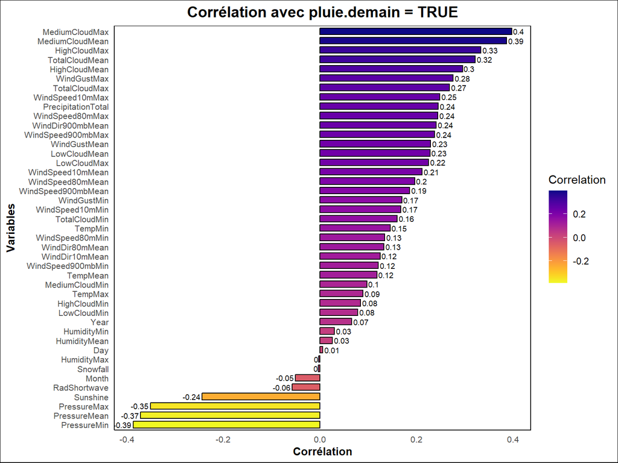

```r
# Conversion de la variable 'pluie.demain' en numérique
pluie.demain_Num_TRUE <- as.numeric(meteo_train$pluie.demain ==
    "TRUE")

# Calcul des corrélations entre toutes les variables et
# 'pluie.demain'
correlationTRUE <- sapply(meteo_train[, sapply(meteo_train, is.numeric)],
    function(x) {
        cor.test(x, pluie.demain_Num_TRUE, method = "pearson")$estimate
    })
names(correlationTRUE) <- gsub(".cor$", "", names(correlationTRUE))
cor_df_TRUE <- data.frame(Variable = names(correlationTRUE),
    Correlation = unlist(correlationTRUE))
cor_df_TRUE <- cor_df_TRUE[order(abs(cor_df_TRUE$Correlation),
    decreasing = TRUE), ]

ggplot(cor_df_TRUE, aes(x = reorder(Variable, Correlation), y = Correlation,
    fill = Correlation)) + geom_col(color = "black", width = 0.7) +
    geom_text(aes(label = round(Correlation, 2)), hjust = ifelse(cor_df_TRUE$Correlation <
        0, 1.1, -0.1), color = "black", size = 2.5) + scale_fill_viridis(option = "plasma",
    direction = -1) + coord_flip() + theme_minimal() + theme(plot.title = element_text(size = 14,
    face = "bold", hjust = 0.5), axis.title.x = element_text(size = 10,
    face = "bold"), axis.title.y = element_text(size = 10, face = "bold"),
    axis.text = element_text(size = 8), panel.grid.major = element_blank(),
    panel.grid.minor = element_blank(), axis.line = element_line(color = "black"),
    plot.background = element_rect(fill = "white"), panel.background = element_rect(fill = "white")) +
    labs(title = "Corrélation avec pluie.demain = TRUE", x = "Variables",
        y = "Corrélation")
```

### 2.2.3 Variables corrélées entre elles

Pour identifier plus précisément les variables fortement corrélées entre elles, nous avons construit une matrice de corrélation, ci-dessous, qui met uniquement en évidence les variables présentant des corrélations positives ou négatives égale ou supérieure à 70%.

Comme précédemment, nous voyons que les variables d’un même groupe ayant un “Mean”, “Max” et “Min” sont fortement corrélés entre elles. Par exemple, la variable de “PressureMean” est corrélée à 97% avec les variables “PressureMax” et “PressureMean”. Il va falloir choisir l’une des 3 variables pour notre modèle.

Concernant les corrélations entre les groupes de variables, nous remarquons que la variable “Sunshine” est fortement corrélée négativement aux variables de couvertures nuageuses “TotalcloudMean”, “MediumCloudMean” et “LowCloudMean” indiquant que des jours ensoleillés sont associés à une faible couverture nuageuse. Cette variable aussi est très corrélée positivement à la variable “Radshorwave” car les jours avec plus d’ensoleillement tendent à recevoir plus de rayonnement solaire.

Nous remarquerons aussi avec ce graph que les variables de nébulosité sont très corréles positivement entre elles et aussi que les variables de rafales de vent sont très corrélés positivement avec les variables indiquant les vitesses du vent.

```r
if (knitr::is_html_output()) {
    # Identification des paires de variables corrélées à
    # plus de 70%
    highly_correlated_var <- function(data_for_corr, threshold = 0.7) {
        cor_matrix <- cor(data_for_corr, use = "complete.obs")
        high_correl <- which(abs(cor_matrix) > threshold, arr.ind = TRUE)
        high_correl <- high_correl[high_correl[, 1] < high_correl[,
            2], ]

        # Calcul des variables corrélées
        high_correl_pairs <- data.frame(Variable1 = rownames(cor_matrix)[high_correl[,
            1]], Variable2 = colnames(cor_matrix)[high_correl[,
            2]], Correlation = cor_matrix[high_correl])
        return(high_correl_pairs)
    }
    high_correl_pairs <- highly_correlated_var(data_for_corr,
        threshold = 0.7)
    kable(high_correl_pairs, caption = "Variables corrélées à plus de 70%")
}
```

Variables corrélées à plus de 70%

| Variable1 | Variable2 | Correlation |
| --- | --- | --- |
| TotalCloudMean | MediumCloudMean | 0.7868108 |
| TotalCloudMean | LowCloudMean | 0.9018688 |
| TotalCloudMean | Sunshine | -0.9064643 |
| MediumCloudMean | Sunshine | -0.7350974 |
| LowCloudMean | Sunshine | -0.8013095 |
| TempMean | RadShortwave | 0.7015678 |
| Sunshine | RadShortwave | 0.7547663 |
| WindSpeed10mMean | WindSpeed80mMean | 0.9816588 |
| WindDir10mMean | WindDir80mMean | 0.9748374 |
| WindSpeed10mMean | WindSpeed900mbMean | 0.7905158 |
| WindSpeed80mMean | WindSpeed900mbMean | 0.7985150 |
| WindSpeed10mMean | WindGustMean | 0.9217280 |
| WindSpeed80mMean | WindGustMean | 0.9198653 |
| WindSpeed900mbMean | WindGustMean | 0.8876685 |
| TempMean | TempMax | 0.9806656 |
| RadShortwave | TempMax | 0.7529370 |
| TempMean | TempMin | 0.9683863 |
| TempMax | TempMin | 0.9121400 |
| HumidityMean | HumidityMax | 0.7739056 |
| HumidityMean | HumidityMin | 0.8939695 |
| PressureMean | PressureMax | 0.9722008 |
| PressureMean | PressureMin | 0.9735478 |
| PressureMax | PressureMin | 0.9047461 |
| HighCloudMean | HighCloudMax | 0.7453130 |
| MediumCloudMean | MediumCloudMax | 0.7000574 |
| TotalCloudMax | LowCloudMax | 0.7675205 |
| TotalCloudMin | LowCloudMin | 0.7356233 |
| WindSpeed10mMean | WindSpeed10mMax | 0.9185578 |
| WindSpeed80mMean | WindSpeed10mMax | 0.8964949 |
| WindSpeed900mbMean | WindSpeed10mMax | 0.7674204 |
| WindGustMean | WindSpeed10mMax | 0.8684929 |
| WindSpeed10mMean | WindSpeed10mMin | 0.8250362 |
| WindSpeed80mMean | WindSpeed10mMin | 0.8153017 |
| WindGustMean | WindSpeed10mMin | 0.7354566 |
| WindSpeed10mMean | WindSpeed80mMax | 0.8850197 |
| WindSpeed80mMean | WindSpeed80mMax | 0.8953142 |
| WindSpeed900mbMean | WindSpeed80mMax | 0.7500414 |
| WindGustMean | WindSpeed80mMax | 0.8362743 |
| WindSpeed10mMax | WindSpeed80mMax | 0.9476338 |
| WindSpeed10mMean | WindSpeed80mMin | 0.8135628 |
| WindSpeed80mMean | WindSpeed80mMin | 0.8251264 |
| WindGustMean | WindSpeed80mMin | 0.7496423 |
| WindSpeed10mMin | WindSpeed80mMin | 0.9333039 |
| WindSpeed10mMean | WindSpeed900mbMax | 0.7264281 |
| WindSpeed80mMean | WindSpeed900mbMax | 0.7317578 |
| WindSpeed900mbMean | WindSpeed900mbMax | 0.9168068 |
| WindGustMean | WindSpeed900mbMax | 0.8153594 |
| WindSpeed10mMax | WindSpeed900mbMax | 0.7699367 |
| WindSpeed80mMax | WindSpeed900mbMax | 0.7799064 |
| WindSpeed10mMean | WindSpeed900mbMin | 0.7278003 |
| WindSpeed80mMean | WindSpeed900mbMin | 0.7307487 |
| WindSpeed900mbMean | WindSpeed900mbMin | 0.8953039 |
| WindGustMean | WindSpeed900mbMin | 0.8089603 |
| WindSpeed900mbMax | WindSpeed900mbMin | 0.7179283 |
| WindSpeed10mMean | WindGustMax | 0.8117673 |
| WindSpeed80mMean | WindGustMax | 0.8106931 |
| WindSpeed900mbMean | WindGustMax | 0.8023582 |
| WindGustMean | WindGustMax | 0.8853670 |
| WindSpeed10mMax | WindGustMax | 0.8713995 |
| WindSpeed80mMax | WindGustMax | 0.8737248 |
| WindSpeed900mbMax | WindGustMax | 0.8412173 |
| WindSpeed10mMean | WindGustMin | 0.7982554 |
| WindSpeed80mMean | WindGustMin | 0.7945536 |
| WindSpeed900mbMean | WindGustMin | 0.7430117 |
| WindGustMean | WindGustMin | 0.8223337 |
| WindSpeed10mMin | WindGustMin | 0.8343751 |
| WindSpeed80mMin | WindGustMin | 0.8339175 |
| WindSpeed900mbMin | WindGustMin | 0.7846463 |

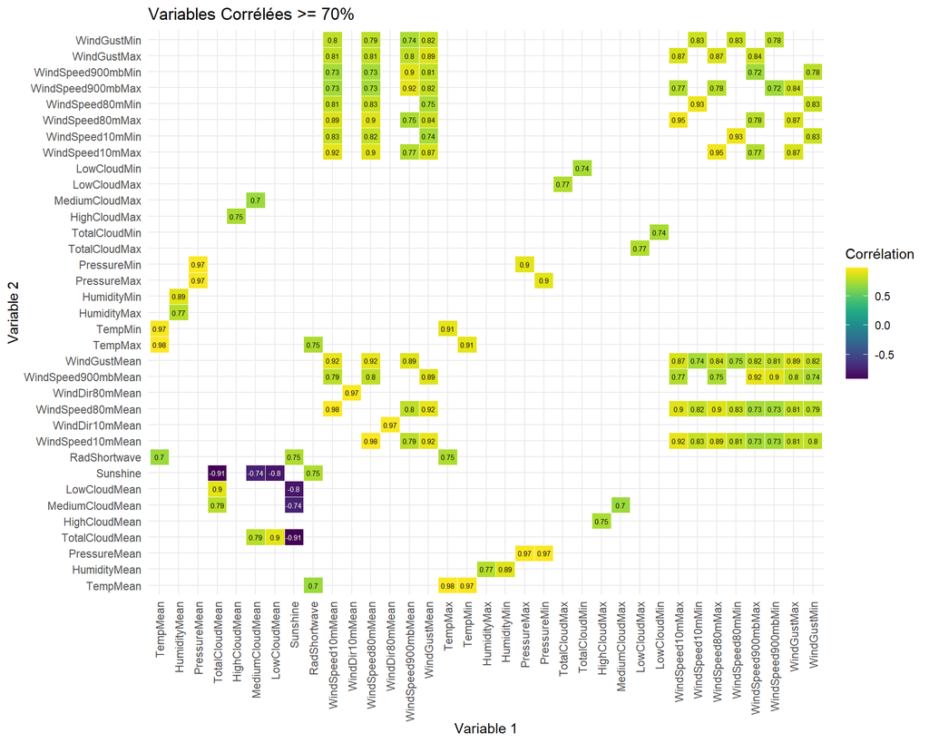

```r
# Identification des paires de variables corrélées à plus
# de 70%
highly_correlated_var <- function(data_for_corr, threshold = 0.7) {
    cor_matrix <- cor(data_for_corr, use = "complete.obs")
    high_correl <- which(abs(cor_matrix) > threshold, arr.ind = TRUE)
    high_correl <- high_correl[high_correl[, 1] < high_correl[,
        2], ]

    # Calcul des variables corrélées
    high_correl_pairs <- data.frame(Variable1 = rownames(cor_matrix)[high_correl[,
        1]], Variable2 = colnames(cor_matrix)[high_correl[, 2]],
        Correlation = cor_matrix[high_correl])
    return(high_correl_pairs)
}
data_for_corr <- meteo_train[, sapply(meteo_train, is.numeric)]
high_correl_pairs <- highly_correlated_var(data_for_corr, threshold = 0.7)

cor_matrix <- cor(data_for_corr, use = "complete.obs")
melted_cor_matrix <- melt(cor_matrix)
melted_cor_matrix <- subset(melted_cor_matrix, abs(value) >=
    0.7 & Var1 != Var2)
melted_cor_matrix$text_color <- ifelse(melted_cor_matrix$value <
    -0.7, "white", "black")

ggplot(data = melted_cor_matrix, aes(x = Var1, y = Var2, fill = value)) +
    geom_tile(color = "white") + geom_text(aes(label = round(value,
    2), color = text_color), size = 2) + scale_fill_viridis(name = "Corrélation",
    option = "viridis") + scale_color_identity() + theme_minimal() +
    theme(axis.text.x = element_text(angle = 90, vjust = 0.5,
        hjust = 1)) + labs(title = "Variables Corrélées >= 70%",
    x = "Variable 1", y = "Variable 2")
```

### 2.2.4 Variables retenues

A la suite de notre étude graphique et corrélation et dans le but de pour constuire un modèle manuel, nous allons sélectionner les variables suivantes:

- MediumCloudMax : Cette variable la plus corrélée avec la variable “pluie.demain = TRUE” et est peu corrélée avec les autres variables y compris “Sunshine”. On ne prendra pas “MediumCloudMean” car ces deux variables sont corrélées à 70% ensemble.
- HighCloudMax: Cette variable est corrélée avec la variable “pluie.demain = TRUE” et est peu corrélée avec les autres variables y compris “Sunshine”. On ne prendra pas “HighCloudMean” car ces deux variables sont corrélées à 75% ensemble.
- TotalCloudMax: Cette variable est corrélée avec la variable “pluie.demain = TRUE” et est peu corrélée avec les autres variables y compris “Sunshine”. On ne prendra pas “LowCloudMax” car ces deux variables sont corrélées à 77% ensemble.
- WindGustMax: Cette variable est corrélée avec la variable “pluie.demain = TRUE”, peu corrélée avec Sunshine et très corrélée avec les variables “WindSpeed”. Cela nous permet de prendre uniquement une variable.
- TempMin: Cette variable est la plus corrélée des variables de Température avec “pluie.demain”. Nous avons sélectionner une seule variable car elle est très corrélée avec “TempMax” et “TempMean”.
- PressureMin: Cette variable est la plus corrélée négativement avec “pluie.demain = TRUE”. Nous avons sélectionner une seule variable car elle est très corrélée avec “PressureMax” et “PressureMean”.
- WindDir900mbMean: Cette variable est la plus corrélée des variables de direction du vent avec “pluie.demain = TRUE” et n’est pas corrélée à plus de 70% avec les autres variables.
- Sunshine: Cette variable est corrélée négativement avec “pluie.demain = TRUE”. Elle n’a pas de corrélation avec les variables “CloudMax” mais avec les variables “CloudMean”. Elle a une corrélation positive à 75% avec la variable RadShortwave qui est donc exclus.
- PrecipitationTotal: Cette variable a une corrélation positive avec “pluie.demain = TRUE” et n’a pas corrélation à plus de 70% avec les autres variables.

Notre model manuel prendra en compte toutes ces variables.

# 3. Choix du modèle

Pour prédire notre variable réponse “pluie.demain”, qui est de type binaire et qui suit une Loi de Bernoulli, nous allons nous intéresser au modèle linéaire généralisé utilisant la fonction de lien “logit” dans un premier temps et la fonction de lien “probit” dans un deuxième temps.

## 3.1 Choix du modèle Logistique

Le modèle logistique est défini par: $Y_i \sim \text{Bernoulli}(p_i) ~ln \left(\frac{p_i}{1 - p_i}\right) = \beta_0 + \beta_1 x_i$ ce qu’on peut aussi écrire en $P(Y_i = 1) = \frac{e^{\beta_0 + \beta_1 x_i}}{1 + e^{\beta_0 + \beta_1 x_i}}$.

Les coefficients $\beta$ sont estimés en maximisant la vraisemblance et représentent le changement du logarithme de côtes, dit logit, pour une unité de changement dans la variable dépendante en tenant constantes toutes les autres variables.

Dans les summary présenté pour chaque modèle, on calculera également le rapport de côtes (odds ratio) qui a pour formule $e^{\beta_i}$. Cette notion est utilisée pour mesurer l’impact d’une covariable sur la probabilité d’un évènement.Un rapport de cotes > 1 indique que la probabilité augmente, et < 1 qu’elle diminue. On calculera également la probabilité correspondante $p_i = P(Y_i = 1) = \left(\frac{\exp(\beta_i)}{1 + \exp(\beta_i)}\right)$ pour avoir une meilleure lisibilité.

### 3.1.1 Modèle initial

Nous commencerons par regarder un model_initial, qui prend en compte toutes les variables encore présente dans “meteo_train”.

```r
model_initial <- glm(pluie.demain ~ ., family = binomial, data = meteo_train)
```

Ci dessous est présenté, le summary du model_initial avec les coefficients, les odds ratio, la probabilité et la significativité. Le modèle a atteint la convergence vers l’estimateur du maximum de vraisemblance après cinq itérations du scoring de Fisher.

Estimate

Std..Error

z.value

p.value

Odds.Ratio

Probability….

Significance

(Intercept)

-76.461

70.610

-1.083

0.279

0.000

0.000

Year

0.069

0.035

1.985

0.047

1.072

51.730

Month

-0.019

0.025

-0.746

0.456

0.982

49.535

Day

0.012

0.008

1.445

0.148

1.012

50.295

TempMean

0.183

0.164

1.116

0.264

1.201

54.562

HumidityMean

0.020

0.032

0.612

0.540

1.020

50.496

PressureMean

0.512

0.139

3.675

0.000

1.669

62.536

***

PrecipitationTotal

0.026

0.028

0.922

0.356

1.026

50.647

Snowfall

-0.285

0.234

-1.220

0.223

0.752

42.916

TotalCloudMean

0.012

0.012

1.039

0.299

1.013

50.312

HighCloudMean

-0.003

0.007

-0.477

0.633

0.997

49.919

MediumCloudMean

0.006

0.007

0.835

0.404

1.006

50.140

LowCloudMean

-0.004

0.008

-0.535

0.593

0.996

49.892

Sunshine

0.000

0.001

0.556

0.578

1.000

50.012

RadShortwave

0.000

0.000

0.297

0.766

1.000

50.001

WindSpeed10mMean

-0.046

0.097

-0.478

0.632

0.955

48.840

WindDir10mMean

0.006

0.006

0.977

0.328

1.006

50.141

WindSpeed80mMean

-0.094

0.069

-1.357

0.175

0.910

47.644

WindDir80mMean

-0.009

0.006

-1.592

0.111

0.991

49.763

WindSpeed900mbMean

0.018

0.026

0.707

0.479

1.019

50.459

WindDir900mbMean

0.005

0.001

3.723

0.000

1.005

50.135

***

WindGustMean

0.018

0.037

0.483

0.629

1.018

50.445

TempMax

-0.011

0.096

-0.119

0.905

0.989

49.714

TempMin

-0.130

0.086

-1.509

0.131

0.878

46.749

HumidityMax

0.000

0.021

0.003

0.997

1.000

50.002

HumidityMin

-0.007

0.019

-0.370

0.711

0.993

49.828

PressureMax

-0.259

0.075

-3.449

0.001

0.772

43.568

***

PressureMin

-0.321

0.076

-4.234

0.000

0.726

42.052

***

TotalCloudMax

0.003

0.005

0.701

0.483

1.003

50.085

TotalCloudMin

0.008

0.006

1.243

0.214

1.008

50.195

HighCloudMax

0.003

0.003

1.186

0.236

1.003

50.086

HighCloudMin

0.006

0.021

0.294

0.769

1.006

50.154

MediumCloudMax

0.006

0.003

1.946

0.052

1.006

50.154

.

MediumCloudMin

-0.005

0.009

-0.560

0.576

0.995

49.868

LowCloudMax

0.003

0.003

0.867

0.386

1.003

50.074

LowCloudMin

0.000

0.007

0.017

0.986

1.000

50.003

WindSpeed10mMax

0.056

0.034

1.620

0.105

1.057

51.397

WindSpeed10mMin

0.169

0.064

2.635

0.008

1.184

54.216

WindSpeed80mMax

0.004

0.028

0.138

0.890

1.004

50.098

WindSpeed80mMin

-0.053

0.042

-1.257

0.209

0.948

48.674

WindSpeed900mbMax

-0.013

0.012

-1.106

0.269

0.987

49.665

WindSpeed900mbMin

-0.004

0.019

-0.212

0.832

0.996

49.899

WindGustMax

0.023

0.017

1.319

0.187

1.023

50.570

WindGustMin

0.005

0.028

0.182

0.855

1.005

50.128

```r
model_initial <- glm(pluie.demain ~ ., family = binomial, data = meteo_train)

model_stats <- data.frame(Statistic = c("Null Deviance", "Residual Deviance",
    "Number of Fisher Scoring Iterations", "AIC"), Value = c(model_initial$null.deviance,
    model_initial$deviance, model_initial$iter, AIC(model_initial)),
    DF = c(model_initial$df.null, model_initial$df.residual,
        NA, NA))

kable(model_stats)
```

| Statistic | Value | DF |
| --- | --- | --- |
| Null Deviance | 1635.417 | 1179 |
| Residual Deviance | 1232.696 | 1136 |
| Number of Fisher Scoring Iterations | 5.000 | NA |
| AIC | 1320.696 | NA |

On remarque dans ce model_initial qu’il y a uniquement 7 coefficients statistiquement significatifs. Le modèle semble assez complexe et semble avoir beaucoup de colinéarité.

```r
if (knitr::is_html_output()) {
    # Vérification de la colinéarité
    vif(model_initial)
}
```

```
##               Year              Month                Day           TempMean
##           1.385500           1.400129           1.042521         258.417001
##       HumidityMean       PressureMean PrecipitationTotal           Snowfall
##          19.924910         189.959417           2.064756           1.334349
##     TotalCloudMean      HighCloudMean    MediumCloudMean       LowCloudMean
##          27.129339           4.241448           7.242176          12.632309
##           Sunshine       RadShortwave   WindSpeed10mMean     WindDir10mMean
##          12.167581           9.548102          59.136316          26.035708
##   WindSpeed80mMean     WindDir80mMean WindSpeed900mbMean   WindDir900mbMean
##          51.791321          28.529624          30.581269           2.311240
##       WindGustMean            TempMax            TempMin        HumidityMax
##          24.220598         109.917602          58.610434           5.055424
##        HumidityMin        PressureMax        PressureMin      TotalCloudMax
##          11.052603          52.270246          61.303286           3.102089
##      TotalCloudMin       HighCloudMax       HighCloudMin     MediumCloudMax
##           3.722177           3.082844           1.468625           3.328208
##     MediumCloudMin        LowCloudMax        LowCloudMin    WindSpeed10mMax
##           1.680939           3.202888           2.656601          17.024611
##    WindSpeed10mMin    WindSpeed80mMax    WindSpeed80mMin  WindSpeed900mbMax
##           9.812252          15.627770          10.065454          12.932286
##  WindSpeed900mbMin        WindGustMax        WindGustMin
##           9.169254          10.874209           6.661382
```

```r
if (knitr::is_html_output()) {
    # Impact sur la deviance
    anova(model_initial, test = "LRT")
}
```

```
## Analysis of Deviance Table
##
## Model: binomial, link: logit
##
## Response: pluie.demain
##
## Terms added sequentially (first to last)
##
##
##                    Df Deviance Resid. Df Resid. Dev  Pr(>Chi)
## NULL                                1179     1635.4
## Year                1    5.156      1178     1630.3 0.0231706 *
## Month               1    1.827      1177     1628.4 0.1764629
## Day                 1    0.066      1176     1628.4 0.7970562
## TempMean            1   19.877      1175     1608.5 8.257e-06 ***
## HumidityMean        1   16.450      1174     1592.0 4.996e-05 ***
## PressureMean        1  158.185      1173     1433.9 < 2.2e-16 ***
## PrecipitationTotal  1   22.305      1172     1411.5 2.326e-06 ***
## Snowfall            1    2.597      1171     1409.0 0.1070666
## TotalCloudMean      1   51.043      1170     1357.9 9.037e-13 ***
## HighCloudMean       1    7.248      1169     1350.7 0.0070964 **
## MediumCloudMean     1    5.595      1168     1345.1 0.0180136 *
## LowCloudMean        1    0.726      1167     1344.3 0.3940675
## Sunshine            1    1.011      1166     1343.3 0.3145758
## RadShortwave        1    0.036      1165     1343.3 0.8492595
## WindSpeed10mMean    1   11.970      1164     1331.3 0.0005406 ***
## WindDir10mMean      1    0.015      1163     1331.3 0.9010529
## WindSpeed80mMean    1    3.475      1162     1327.8 0.0622926 .
## WindDir80mMean      1    0.110      1161     1327.7 0.7405183
## WindSpeed900mbMean  1    2.564      1160     1325.2 0.1093561
## WindDir900mbMean    1   18.062      1159     1307.1 2.138e-05 ***
## WindGustMean        1    2.565      1158     1304.5 0.1092761
## TempMax             1    5.686      1157     1298.8 0.0171045 *
## TempMin             1    0.641      1156     1298.2 0.4232223
## HumidityMax         1    0.070      1155     1298.1 0.7914619
## HumidityMin         1    0.665      1154     1297.5 0.4147025
## PressureMax         1    0.244      1153     1297.2 0.6216246
## PressureMin         1   24.970      1152     1272.3 5.824e-07 ***
## TotalCloudMax       1    9.596      1151     1262.7 0.0019501 **
## TotalCloudMin       1    1.821      1150     1260.8 0.1772066
## HighCloudMax        1    5.960      1149     1254.9 0.0146350 *
## HighCloudMin        1    0.033      1148     1254.8 0.8564048
## MediumCloudMax      1    4.399      1147     1250.5 0.0359613 *
## MediumCloudMin      1    0.418      1146     1250.0 0.5177784
## LowCloudMax         1    0.942      1145     1249.1 0.3317606
## LowCloudMin         1    0.004      1144     1249.1 0.9503930
## WindSpeed10mMax     1    4.590      1143     1244.5 0.0321647 *
## WindSpeed10mMin     1    7.141      1142     1237.3 0.0075332 **
## WindSpeed80mMax     1    0.566      1141     1236.8 0.4518061
## WindSpeed80mMin     1    1.701      1140     1235.1 0.1922039
## WindSpeed900mbMax   1    0.564      1139     1234.5 0.4525364
## WindSpeed900mbMin   1    0.028      1138     1234.5 0.8663886
## WindGustMax         1    1.766      1137     1232.7 0.1838166
## WindGustMin         1    0.033      1136     1232.7 0.8554437
## ---
## Signif. codes:  0 '***' 0.001 '**' 0.01 '*' 0.05 '.' 0.1 ' ' 1
```

```r
pvalMoMkinitial <- pchisq(1635.4 - 1232.7, 1179 - 1136, lower = F)
cat("La p-valeur pour la différence de déviance est :", format(pvalMoMkinitial,
    scientific = TRUE))
```

```
## La p-valeur pour la différence de déviance est : 6.130973e-60
```

On testera d’abord $M_O$ contre $M_k$ en utilisant la statistique de test suivante: $D_0 - D_k = -2 \ln \left(\frac{\text{vraisemblance } M_{\text{0}}}{\text{vraisemblance } M_k}\right)$ où $D_0$ est la déviance nulle et $D_k$ est la déviance résiduelle. Sous l’hypothèse que $M_0$ est le vrai modèle on a $D_0 - D_k \sim \chi^2(k)$. La déviance null du modele_intial est de 1635.4 avec 1179 degrés de liberté et la déviance résiduelle est de 1232.7 pour 1136 degrés de liberté. Avec une p-valeur inférieur à 0.05, le model_initial avec plus de variable est meilleur en termes d’ajustement par rapport au modèle modèle $M_0$ qui n’inclut que l’intercept.

```r
pvalMkMsatinitial <- pchisq(1232.7, 1136, lower = F)
cat("La p-valeur est:", sprintf("%.3f", pvalMkMsatinitial))
```

```
## La p-valeur est: 0.023
```

On testera ensuite $M_k$ contre $M_{sat}$ en utilisant la statistique de test suivante: $D_k = -2 \ln \left(\frac{\text{vraisemblance de } M_k}{\text{vraisemblance de } M_{\text{sat}}}\right)$ où $D_k$ est la déviance résiduelle. Sous l’hypothèse que $M_k$ ) est le vrai modèle, on a $D_k \sim \chi^2_{n-k-1}$. La déviance résiduelle du model_inital est de 1232.7 pour 1136 degrés de liberté. On remarquera que la p-valeur est de 0.023 et donc inférieur à 0.05. On rejette donc notre modèle initial car on lui préfère le modèle saturé. Notre modèle n’est pas suffisant.

- Prédiction: Malgré le fait que le model_inital soit rejeté, nous allons tout de même calculer les prédictions pour ce modèle pour pouvoir comparer avec les autre modèle. On cherche ici à faire une prédiction binaire. Si notre prédiction est $\tilde{Y} \sim \text{Bernoulli}(\tilde{p})$ avec $\tilde{p} = \frac{e^{\hat{\beta} \tilde{X}}}{1 + e^{\hat{\beta} \tilde{X}}}$, on va souvent prédire 1 si $\tilde{p} \geq \frac{1}{2}$ et 0 si $\tilde{p} < \frac{1}{2}$. Voici la table de décision ci-dessous avec un seuil de décision fixé à 0.5 pour comparer les modèles. Nous avons des FPR (False Positive Rate) = $P(\tilde{Y} = 1 \mid Y = 0)$ = 158/579 = 27%, un spécificité 421/579 = 0.72 = 1-FPR et sensitivité TPR (True Positive Rate) = $P(\tilde{Y} = 1 \mid Y = 1)$ = 464/601 = 77%. En tout le modele_inital donne 75% de bonnes prédictions.

```r
pred_prob_initial = predict(model_initial, newdata = meteo_train,
    type = "response")
pred_initial = (pred_prob_initial >= 0.5)
table_initial <- table(pred_initial, meteo_train$pluie.demain)
table_initial_print <- as.data.frame.matrix(table_initial)
kable(table_initial_print, caption = "Table de Décision - Model_initial")
```

Table de Décision - Model_initial

|  | FALSE | TRUE |
| --- | --- | --- |
| FALSE | 421 | 137 |
| TRUE | 158 | 464 |

```r
accuracy_model_initial <- (mean(pred_initial == (meteo_train$pluie.demain ==
    "TRUE"))) * 100
cat("Bonnes prédictions:", sprintf("%.2f%%", accuracy_model_initial))
```

```
## Bonnes prédictions: 75.00%
```

Nous pouvons aussi peut définir un seuil $s$ optimal. On pourrait mettre des poids pour pénaliser les mauvaises prédictions mais nous le ferrons pas dans ce rapport. Le seuil optimal reste donc proche de 0.5 et est de 0.49. Une fausse prédiction est enlevée. Nous avons aussi calculé la courbe ROC (receiving operator characteristic) avec en abscisse les FPR et en ordonnée les TPR. On voit que la courbe est au dessus de la droite d’équation $y=x$, notre modele_initial fait donc mieux que l’aléatoire et l’AUC (Area Under Curve) qui mesure la qualité de la classification est de 82%, ce qui est un très bon score puisqu’il est au-dessous de la classification aléatoire (AUC=50%).

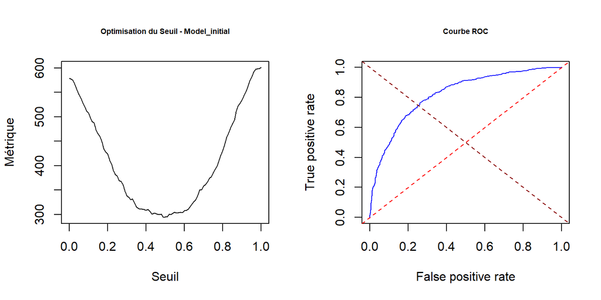

```r
par(mfrow = c(1, 2))
# Optimisation du seuil
seuils <- seq(0, 1, by = 0.01)
res_initial <- rep(NA, length(seuils))

for (i in 1:length(seuils)) {
    pred_initial <- (pred_prob_initial >= seuils[i])
    res_initial[i] <- sum(pred_initial & (meteo_train$pluie.demain ==
        "FALSE")) + sum(!pred_initial & (meteo_train$pluie.demain ==
        "TRUE"))
}

# Tracé du graph en fonction du seuil
plot(seuils, res_initial, type = "l", main = "Optimisation du Seuil - Model_initial",
    xlab = "Seuil", ylab = "Métrique", cex.main = 0.6)
best_seuil_initial <- seuils[which.min(res_initial)]
# cat('Meilleur seuil:', best_seuil_initial, '\n')

cout = function(s) {
    pred_initial <- (pred_prob_initial >= s)
    # Coût = 1 * nombre de faux positifs + 1 * nombre de
    # faux négatifs
    1 * sum(pred_initial & (meteo_train$pluie.demain == "FALSE")) +
        1 * sum(!pred_initial & (meteo_train$pluie.demain ==
            "TRUE"))
}

cost_0_5 <- cout(0.5)
# cat('Coût pour le seuil de 0.5:', cost_0_5, '\n')

# Calculer et afficher le coût pour le meilleur seuil
cost_best_seuil <- cout(best_seuil_initial)
# cat('Coût pour le meilleur seuil:', cost_best_seuil,
# '\n')

# Calcul et tracé de la courbe ROC
pred_roc_initial <- prediction(pred_prob_initial, meteo_train$pluie.demain)
perf_initial <- performance(pred_roc_initial, "tpr", "fpr")
plot(perf_initial, col = "blue", main = "Courbe ROC", cex.main = 0.6)
abline(0, 1, lty = 2, col = "red")  # Ligne de référence
abline(1, -1, lty = 2, col = "darkred")
```

```r
# Calcul de l'AUC
auc_initial <- performance(pred_roc_initial, "auc")
auc_value_initial <- auc_initial@y.values[[1]]
# cat('AUC - model_initial:', auc_value_initial, '\n')

results_initial <- data.frame(Metric = c("Meilleur seuil", "Coût pour le seuil de 0.5",
    "Coût pour le meilleur seuil", "AUC - model_initial"), Value = c(sprintf("%.2f",
    best_seuil_initial), cost_0_5, cost_best_seuil, sprintf("%.2f",
    auc_value_initial)))

kable(results_initial, caption = "Seuil, Coût 0.5, Coût Seuil Optimal, AUC")
```

Seuil, Coût 0.5, Coût Seuil Optimal, AUC

| Metric | Value |
| --- | --- |
| Meilleur seuil | 0.49 |
| Coût pour le seuil de 0.5 | 295 |
| Coût pour le meilleur seuil | 294 |
| AUC - model_initial | 0.82 |

### 3.1.2 Modèle Manuel

Nous continuerons par regarder un model_manuel, qui prend uniquement en compte les variables de la partie graphique et corrélation.

```r
model_manuel <- glm(pluie.demain ~ MediumCloudMax + HighCloudMax +
    TotalCloudMax + WindGustMax + TempMin + PressureMin + WindDir900mbMean +
    Sunshine + PrecipitationTotal, family = binomial, data = meteo_train)
```

Ci dessous est présenté, le summary du model_manuel avec les coefficients, les odds ratio, la probabilité et la significativité. Le modèle a atteint la convergence vers l’estimateur du maximum de vraisemblance après 4 itérations du scoring de Fisher.

Estimate

Std..Error

z.value

p.value

Odds.Ratio

Probability….

Significance

(Intercept)

67.758

10.413

6.507

0.000

2.671794e+29

100.000

***

MediumCloudMax

0.008

0.003

2.975

0.003

1.008000e+00

50.193

HighCloudMax

0.004

0.002

2.067

0.039

1.004000e+00

50.107

TotalCloudMax

0.005

0.003

1.374

0.170

1.005000e+00

50.118

WindGustMax

0.019

0.006

3.214

0.001

1.019000e+00

50.467

TempMin

0.048

0.013

3.630

0.000

1.050000e+00

51.208

***

PressureMin

-0.069

0.010

-6.792

0.000

9.330000e-01

48.267

***

WindDir900mbMean

0.002

0.001

2.154

0.031

1.002000e+00

50.055

Sunshine

0.000

0.000

-0.463

0.644

1.000000e+00

49.996

PrecipitationTotal

0.015

0.022

0.673

0.501

1.015000e+00

50.363

```r
model_manuel <- glm(pluie.demain ~ MediumCloudMax + HighCloudMax +
    TotalCloudMax + WindGustMax + TempMin + PressureMin + WindDir900mbMean +
    Sunshine + PrecipitationTotal, family = binomial, data = meteo_train)

model_stats_manuel <- data.frame(Statistic = c("Null Deviance",
    "Residual Deviance", "Number of Fisher Scoring Iterations",
    "AIC"), Value = c(model_manuel$null.deviance, model_manuel$deviance,
    model_manuel$iter, AIC(model_manuel)), DF = c(model_manuel$df.null,
    model_manuel$df.residual, NA, NA))

kable(model_stats_manuel)
```

| Statistic | Value | DF |
| --- | --- | --- |
| Null Deviance | 1635.417 | 1179 |
| Residual Deviance | 1303.084 | 1170 |
| Number of Fisher Scoring Iterations | 4.000 | NA |
| AIC | 1323.084 | NA |

On remarque dans ce model_manuel qu’il y a 6 coefficients statistiquement significatifs sur 9 variables. Le modèle est moins complexe mais à un AIC un peu moins bon.

```r
if (knitr::is_html_output()) {
    # Vérification de la colinéarité
    vif(model_manuel)
}
```

```
##     MediumCloudMax       HighCloudMax      TotalCloudMax        WindGustMax
##           2.325892           1.667597           1.608576           1.346554
##            TempMin        PressureMin   WindDir900mbMean           Sunshine
##           1.478205           1.192372           1.207652           2.067794
## PrecipitationTotal
##           1.389612
```

- Colinéarité : En utilisant la fonction VIF décrite plus haut. On remarque que tous les vifs sont inférieurs à 2.32. Ce modèle n’a pas de colinéarité. Les résultats détaillés sont présentés dans le version html du document.

```r
if (knitr::is_html_output()) {
    # Impact sur la deviance
    anova(model_manuel, test = "LRT")
    anova(model_initial, model_manuel, test = "LRT")
}
```

```
## Analysis of Deviance Table
##
## Model 1: pluie.demain ~ Year + Month + Day + TempMean + HumidityMean +
##     PressureMean + PrecipitationTotal + Snowfall + TotalCloudMean +
##     HighCloudMean + MediumCloudMean + LowCloudMean + Sunshine +
##     RadShortwave + WindSpeed10mMean + WindDir10mMean + WindSpeed80mMean +
##     WindDir80mMean + WindSpeed900mbMean + WindDir900mbMean +
##     WindGustMean + TempMax + TempMin + HumidityMax + HumidityMin +
##     PressureMax + PressureMin + TotalCloudMax + TotalCloudMin +
##     HighCloudMax + HighCloudMin + MediumCloudMax + MediumCloudMin +
##     LowCloudMax + LowCloudMin + WindSpeed10mMax + WindSpeed10mMin +
##     WindSpeed80mMax + WindSpeed80mMin + WindSpeed900mbMax + WindSpeed900mbMin +
##     WindGustMax + WindGustMin
## Model 2: pluie.demain ~ MediumCloudMax + HighCloudMax + TotalCloudMax +
##     WindGustMax + TempMin + PressureMin + WindDir900mbMean +
##     Sunshine + PrecipitationTotal
##   Resid. Df Resid. Dev  Df Deviance  Pr(>Chi)
## 1      1136     1232.7
## 2      1170     1303.1 -34  -70.388 0.0002431 ***
## ---
## Signif. codes:  0 '***' 0.001 '**' 0.01 '*' 0.05 '.' 0.1 ' ' 1
```

```r
pvalMoMkmanuel <- pchisq(1635.4 - 1303.084, 1179 - 1170, lower = F)
cat("La p-valeur pour la différence de déviance est :", format(pvalMoMkmanuel,
    scientific = TRUE))
```

```
## La p-valeur pour la différence de déviance est : 3.579865e-66
```

La déviance null du modele_manuel est de 1635.4 avec 1179 degrés de liberté et la déviance résiduelle est de 1303.084 pour 1170 degrés de liberté. Avec une p-valeur inférieur à 0.05, le model_manuel avec plus de variables est meilleur en termes d’ajustement par rapport au modèle modèle $M_0$.

```r
pvalMkMsatmanuel <- pchisq(1303.084, 1170, lower = F)
cat("La p-valeur est:", sprintf("%.3f", pvalMkMsatmanuel))
```

```
## La p-valeur est: 0.004
```

On testera ensuite $M_k$ contre $M_{sat}$. La déviance résiduelle du model_manuel eest de 1303.084 pour 1170 degrés de liberté. On remarquera que la p-valeur est de 0.004 et donc inférieur à 0.05. On rejette donc notre model_manuel car on lui préfère le modèle saturé. Notre modèle n’est pas suffisant.

- Prédiction: Malgré le fait que le model_manuel soit rejeté, nous allons tout de même calculer les prédictions pour ce modèle pour pouvoir comparer avec les autre modèle. Voici la table de décision ci-dessous avec un seuil de décision fixé à 0.5 pour comparer les modèles. Nous avons des FPR (False Positive Rate) = $P(\tilde{Y} = 1 \mid Y = 0)$ = 183/579 = 31%, un spécificité 396/579 = 0.68 = 1-FPR et sensitivité TPR (True Positive Rate) = $P(\tilde{Y} = 1 \mid Y = 1)$ = 472/601 = 78%. En tout le modele_manuel donne 73.6% de bonnes prédictions. Ce modèle a un meilleur TPR que le model_initial mais le poucentage de bonnes prédictions est un peu plus faible de 1.4%.

```r
pred_prob_manuel = predict(model_manuel, newdata = meteo_train,
    type = "response")
pred_manuel = (pred_prob_manuel >= 0.5)
table_manuel <- table(pred_manuel, meteo_train$pluie.demain)
table_manuel_print <- as.data.frame.matrix(table_manuel)
kable(table_manuel_print, caption = "Table de Décision - Model_manuel")
```

Table de Décision - Model_manuel

|  | FALSE | TRUE |
| --- | --- | --- |
| FALSE | 396 | 129 |
| TRUE | 183 | 472 |

```r
accuracy_model_manuel <- (mean(pred_manuel == (meteo_train$pluie.demain ==
    "TRUE"))) * 100
cat("Bonnes prédictions:", sprintf("%.2f%%", accuracy_model_manuel))
```

```
## Bonnes prédictions: 73.56%
```

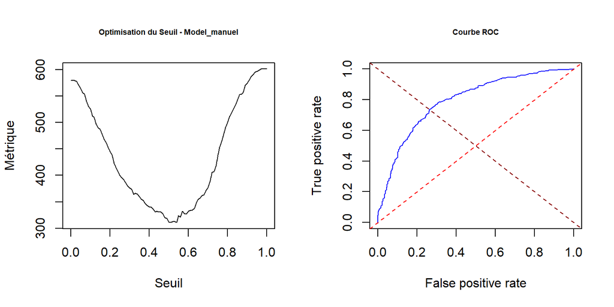

```r
par(mfrow = c(1, 2))
# Optimisation du seuil
seuils <- seq(0, 1, by = 0.01)
res_manuel <- rep(NA, length(seuils))

for (i in 1:length(seuils)) {
    pred_manuel <- (pred_prob_manuel >= seuils[i])
    res_manuel[i] <- sum(pred_manuel & (meteo_train$pluie.demain ==
        "FALSE")) + sum(!pred_manuel & (meteo_train$pluie.demain ==
        "TRUE"))
}

# Tracé du graph en fonction du seuil
plot(seuils, res_manuel, type = "l", main = "Optimisation du Seuil - Model_manuel",
    xlab = "Seuil", ylab = "Métrique", cex.main = 0.6)
best_seuil_manuel <- seuils[which.min(res_manuel)]
# cat('Meilleur seuil:', best_seuil_manuel, '\n')

cout = function(s) {
    pred_manuel <- (pred_prob_manuel >= s)
    # Coût = 1 * nombre de faux positifs + 1 * nombre de
    # faux négatifs
    1 * sum(pred_manuel & (meteo_train$pluie.demain == "FALSE")) +
        1 * sum(!pred_manuel & (meteo_train$pluie.demain == "TRUE"))
}

cost_0_5_manuel <- cout(0.5)
# cat('Coût pour le seuil de 0.5:', cost_0_5, '\n')

# Calculer et afficher le coût pour le meilleur seuil
cost_best_seuil_manuel <- cout(best_seuil_manuel)
# cat('Coût pour le meilleur seuil:',
# cost_best_seuil_manuel, '\n')

# Calcul et tracé de la courbe ROC
pred_roc_manuel <- prediction(pred_prob_manuel, meteo_train$pluie.demain)
perf_manuel <- performance(pred_roc_manuel, "tpr", "fpr")
plot(perf_manuel, col = "blue", main = "Courbe ROC", cex.main = 0.6)
abline(0, 1, lty = 2, col = "red")  # Ligne de référence
abline(1, -1, lty = 2, col = "darkred")
```

```r
# Calcul de l'AUC
auc_manuel <- performance(pred_roc_manuel, "auc")
auc_value_manuel <- auc_manuel@y.values[[1]]
# cat('AUC - model_manuel:', auc_value_manuel, '\n')

results_manuel <- data.frame(Metric = c("Meilleur seuil", "Coût pour le seuil de 0.5",
    "Coût pour le meilleur seuil", "AUC - model_manuel"), Value = c(sprintf("%.2f",
    best_seuil_manuel), cost_0_5_manuel, cost_best_seuil_manuel,
    sprintf("%.2f", auc_value_manuel)))

kable(results_manuel, caption = "Seuil, Coût 0.5, Coût Seuil Optimal, AUC")
```

Seuil, Coût 0.5, Coût Seuil Optimal, AUC

| Metric | Value |
| --- | --- |
| Meilleur seuil | 0.51 |
| Coût pour le seuil de 0.5 | 312 |
| Coût pour le meilleur seuil | 311 |
| AUC - model_manuel | 0.79 |

### 3.1.3 Modèle automatique - Step Backward

Nous continuerons par regarder un model_step_backward automatique, car les précédents modèles ne semblent pas totalement bien capter les ajustements de la variable réponse “pluie.demain”. La fonction step sans précision génére directement la version “both”. On privilégie la fonction step “backward” à la version “forward”. Quant à la la version avec “both”, elle donne le même modèle que la version “backward”. Comme on commence avec un modèle complexe et riches en variables, on va réaliser le step backward à partir du model_initial et cela permet de simplifier progressivement tout en capturant les interactions importantes dés le départ. On présentera tous les résultats uniquement dans le html.

```r
if (knitr::is_html_output()) {
    model_step_back <- step(model_initial, direction = "backward")
}
```

```
## Start:  AIC=1320.7
## pluie.demain ~ Year + Month + Day + TempMean + HumidityMean +
##     PressureMean + PrecipitationTotal + Snowfall + TotalCloudMean +
##     HighCloudMean + MediumCloudMean + LowCloudMean + Sunshine +
##     RadShortwave + WindSpeed10mMean + WindDir10mMean + WindSpeed80mMean +
##     WindDir80mMean + WindSpeed900mbMean + WindDir900mbMean +
##     WindGustMean + TempMax + TempMin + HumidityMax + HumidityMin +
##     PressureMax + PressureMin + TotalCloudMax + TotalCloudMin +
##     HighCloudMax + HighCloudMin + MediumCloudMax + MediumCloudMin +
##     LowCloudMax + LowCloudMin + WindSpeed10mMax + WindSpeed10mMin +
##     WindSpeed80mMax + WindSpeed80mMin + WindSpeed900mbMax + WindSpeed900mbMin +
##     WindGustMax + WindGustMin
##
##                      Df Deviance    AIC
## - HumidityMax         1   1232.7 1318.7
## - LowCloudMin         1   1232.7 1318.7
## - TempMax             1   1232.7 1318.7
## - WindSpeed80mMax     1   1232.7 1318.7
## - WindGustMin         1   1232.7 1318.7
## - WindSpeed900mbMin   1   1232.7 1318.7
## - RadShortwave        1   1232.8 1318.8
## - HighCloudMin        1   1232.8 1318.8
## - HumidityMin         1   1232.8 1318.8
## - HighCloudMean       1   1232.9 1318.9
## - WindSpeed10mMean    1   1232.9 1318.9
## - WindGustMean        1   1232.9 1318.9
## - LowCloudMean        1   1233.0 1319.0
## - MediumCloudMin      1   1233.0 1319.0
## - Sunshine            1   1233.0 1319.0
## - HumidityMean        1   1233.1 1319.1
## - TotalCloudMax       1   1233.2 1319.2
## - WindSpeed900mbMean  1   1233.2 1319.2
## - Month               1   1233.2 1319.2
## - MediumCloudMean     1   1233.4 1319.4
## - LowCloudMax         1   1233.5 1319.5
## - PrecipitationTotal  1   1233.6 1319.6
## - WindDir10mMean      1   1233.7 1319.7
## - TotalCloudMean      1   1233.8 1319.8
## - WindSpeed900mbMax   1   1233.9 1319.9
## - TempMean            1   1233.9 1319.9
```

[output cut: 1095 more lines]

```
## - TempMin           1   1250.5 1284.5
## - TotalCloudMin     1   1251.1 1285.1
## - Year              1   1251.4 1285.4
## - WindGustMax       1   1251.7 1285.7
## - MediumCloudMax    1   1252.4 1286.4
## - TotalCloudMax     1   1252.7 1286.7
## - WindSpeed10mMax   1   1253.9 1287.9
## - MediumCloudMean   1   1254.0 1288.0
## - TempMean          1   1255.7 1289.7
## - WindSpeed10mMin   1   1256.6 1290.6
## - PressureMax       1   1259.1 1293.1
## - WindDir900mbMean  1   1259.8 1293.8
## - PressureMean      1   1261.7 1295.7
## - WindSpeed80mMean  1   1261.9 1295.9
## - PressureMin       1   1268.1 1302.1
```

Le meilleur modèle donné par le fonction step(model_initial, direction = “backward”) est le modèle présenté ci-dessous avec les coefficients, les odds ratio, la probabilité et la significativité. Le modèle a atteint la convergence vers l’estimateur du maximum de vraisemblance après 4 itérations du scoring de Fisher.

```r
model_step_backward <- glm(pluie.demain ~ Year + TempMean + PressureMean +
    Snowfall + MediumCloudMean + WindSpeed80mMean + WindDir80mMean +
    WindDir900mbMean + TempMin + PressureMax + PressureMin +
    TotalCloudMax + TotalCloudMin + MediumCloudMax + WindSpeed10mMax +
    WindSpeed10mMin + WindGustMax, family = binomial, data = meteo_train)
```

Estimate

Std..Error

z.value

p.value

Odds.Ratio

Probability….

Significance

(Intercept)

-68.943

62.792

-1.098

0.272

0.000

0.000

Year

0.066

0.031

2.134

0.033

1.068

51.646

TempMean

0.147

0.050

2.943

0.003

1.158

53.662

PressureMean

0.482

0.131

3.673

0.000

1.619

61.820

***

Snowfall

-0.316

0.215

-1.470

0.142

0.729

42.155

MediumCloudMean

0.011

0.004

2.662

0.008

1.011

50.270

WindSpeed80mMean

-0.115

0.030

-3.824

0.000

0.892

47.140

***

WindDir80mMean

-0.003

0.002

-1.763

0.078

0.997

49.933

.

WindDir900mbMean

0.005

0.001

3.557

0.000

1.005

50.115

***

TempMin

-0.103

0.054

-1.897

0.058

0.902

47.432

.

PressureMax

-0.242

0.071

-3.428

0.001

0.785

43.976

***

PressureMin

-0.306

0.072

-4.276

0.000

0.736

42.409

***

TotalCloudMax

0.008

0.004

2.383

0.017

1.008

50.209

TotalCloudMin

0.008

0.004

2.031

0.042

1.008

50.196

MediumCloudMax

0.006

0.003

2.331

0.020

1.006

50.156

WindSpeed10mMax

0.060

0.023

2.620

0.009

1.061

51.491

WindSpeed10mMin

0.111

0.036

3.081

0.002

1.118

52.779

WindGustMax

0.024

0.011

2.180

0.029

1.024

50.592

```r
model_step_backward <- glm(pluie.demain ~ Year + TempMean + PressureMean +
    Snowfall + MediumCloudMean + WindSpeed80mMean + WindDir80mMean +
    WindDir900mbMean + TempMin + PressureMax + PressureMin +
    TotalCloudMax + TotalCloudMin + MediumCloudMax + WindSpeed10mMax +
    WindSpeed10mMin + WindGustMax, family = binomial, data = meteo_train)

model_stats_step_backward <- data.frame(Statistic = c("Null Deviance",
    "Residual Deviance", "Number of Fisher Scoring Iterations",
    "AIC"), Value = c(model_step_backward$null.deviance, model_step_backward$deviance,
    model_step_backward$iter, AIC(model_step_backward)), DF = c(model_step_backward$df.null,
    model_step_backward$df.residual, NA, NA))
kable(model_stats_step_backward)
```

| Statistic | Value | DF |
| --- | --- | --- |
| Null Deviance | 1635.417 | 1179 |
| Residual Deviance | 1246.847 | 1162 |
| Number of Fisher Scoring Iterations | 4.000 | NA |
| AIC | 1282.847 | NA |

On remarque dans ce model_step_backward qu’il y a 14 coefficients statistiquement significatifs sur 17 variables. L’intercept n’est plus significatif comme dans le modele_manuel. Le modèle est moins complexe et à un meilleur AIC à 1282.8. La variable Snowfall n’est pas significative.

```r
if (knitr::is_html_output()) {
    # Vérification de la colinéarité
    vif(model_step_backward)
}
```

```
##             Year         TempMean     PressureMean         Snowfall
##         1.099122        23.996557       169.930655         1.159206
##  MediumCloudMean WindSpeed80mMean   WindDir80mMean WindDir900mbMean
##         2.674202         9.766353         1.893233         1.847224
##          TempMin      PressureMax      PressureMin    TotalCloudMax
##        23.282257        46.773619        55.333091         1.615412
##    TotalCloudMin   MediumCloudMax  WindSpeed10mMax  WindSpeed10mMin
##         1.414029         2.395002         7.496590         3.152997
##      WindGustMax
##         4.318851
```

```r
if (knitr::is_html_output()) {
    # Impact sur la deviance
    anova(model_step_backward, test = "LRT")
    anova(model_initial, model_step_backward, test = "LRT")
}
```

```
## Analysis of Deviance Table
##
## Model 1: pluie.demain ~ Year + Month + Day + TempMean + HumidityMean +
##     PressureMean + PrecipitationTotal + Snowfall + TotalCloudMean +
##     HighCloudMean + MediumCloudMean + LowCloudMean + Sunshine +
##     RadShortwave + WindSpeed10mMean + WindDir10mMean + WindSpeed80mMean +
##     WindDir80mMean + WindSpeed900mbMean + WindDir900mbMean +
##     WindGustMean + TempMax + TempMin + HumidityMax + HumidityMin +
##     PressureMax + PressureMin + TotalCloudMax + TotalCloudMin +
##     HighCloudMax + HighCloudMin + MediumCloudMax + MediumCloudMin +
##     LowCloudMax + LowCloudMin + WindSpeed10mMax + WindSpeed10mMin +
##     WindSpeed80mMax + WindSpeed80mMin + WindSpeed900mbMax + WindSpeed900mbMin +
##     WindGustMax + WindGustMin
## Model 2: pluie.demain ~ Year + TempMean + PressureMean + Snowfall + MediumCloudMean +
##     WindSpeed80mMean + WindDir80mMean + WindDir900mbMean + TempMin +
##     PressureMax + PressureMin + TotalCloudMax + TotalCloudMin +
##     MediumCloudMax + WindSpeed10mMax + WindSpeed10mMin + WindGustMax
##   Resid. Df Resid. Dev  Df Deviance Pr(>Chi)
## 1      1136     1232.7
## 2      1162     1246.8 -26  -14.152   0.9709
```

```r
pvalMoMkstepback <- pchisq(1635.4 - 1246.85, 1179 - 1162, lower = F)
cat("La p-valeur pour la différence de déviance est :", format(pvalMoMkstepback,
    scientific = TRUE))
```

```
## La p-valeur pour la différence de déviance est : 4.574864e-72
```

```r
pvalMkMsatstepback <- pchisq(1246.85, 1162, lower = F)
cat("La p-valeur est:", sprintf("%.3f", pvalMkMsatstepback))
```

```
## La p-valeur est: 0.042
```

On testera ensuite $M_k$ contre $M_{sat}$. La déviance résiduelle du model_step_backward est de 1246.85 pour 1162 degrés de liberté. On remarquera que la p-valeur est de 0.042 et est toujours inférieure à 0.05 mais se rapproche du seuil de significativité. On rejette donc notre model_step_backward car on lui préfère le modèle saturé. Notre modèle n’est pas encore suffisant.

- Prédiction: Malgré le fait que le model_step_backward soit rejeté, nous allons tout de même calculer les prédictions pour ce modèle pour pouvoir comparer avec les autre modèle. Voici la table de décision ci-dessous avec un seuil de décision fixé à 0.5 pour comparer les modèles. Nous avons des FPR (False Positive Rate) = $P(\tilde{Y} = 1 \mid Y = 0)$ = 162/579 = 27%, un spécificité 417/579 = 0.72 = 1-FPR et sensitivité TPR (True Positive Rate) = $P(\tilde{Y} = 1 \mid Y = 1)$ = 468/601 = 78%. En tout le model_step_backward donne 75% de bonnes prédictions. Ce modèle a un meilleur TPR que le model_initial de 1% et le poucentage de bonnes prédictions est le même.

```r
pred_prob_step_backward = predict(model_step_backward, newdata = meteo_train,
    type = "response")
pred_step_backward = (pred_prob_step_backward >= 0.5)
table_step_backward <- table(pred_step_backward, meteo_train$pluie.demain)
table_step_backward_print <- as.data.frame.matrix(table_step_backward)
kable(table_step_backward_print, caption = "Table de Décision - Model_step_backward")
```

Table de Décision - Model_step_backward

|  | FALSE | TRUE |
| --- | --- | --- |
| FALSE | 417 | 133 |
| TRUE | 162 | 468 |

```r
accuracy_model_step_backward <- (mean(pred_step_backward == (meteo_train$pluie.demain ==
    "TRUE"))) * 100
cat("Bonnes prédictions:", sprintf("%.2f%%", accuracy_model_step_backward))
```

```
## Bonnes prédictions: 75.00%
```

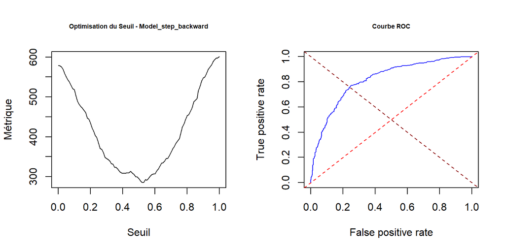

```r
par(mfrow = c(1, 2))
# Optimisation du seuil
seuils <- seq(0, 1, by = 0.01)
res_step_backward <- rep(NA, length(seuils))

for (i in 1:length(seuils)) {
    pred_step_backward <- (pred_prob_step_backward >= seuils[i])
    res_step_backward[i] <- sum(pred_step_backward & (meteo_train$pluie.demain ==
        "FALSE")) + sum(!pred_step_backward & (meteo_train$pluie.demain ==
        "TRUE"))
}

# Tracé du graph en fonction du seuil
plot(seuils, res_step_backward, type = "l", main = "Optimisation du Seuil - Model_step_backward",
    xlab = "Seuil", ylab = "Métrique", cex.main = 0.6)
best_seuil_step_backward <- seuils[which.min(res_step_backward)]
# cat('Meilleur seuil:', best_seuil_step_backward, '\n')

cout = function(s) {
    pred_step_backward <- (pred_prob_step_backward >= s)
    # Coût = 1 * nombre de faux positifs + 1 * nombre de
    # faux négatifs
    1 * sum(pred_step_backward & (meteo_train$pluie.demain ==
        "FALSE")) + 1 * sum(!pred_step_backward & (meteo_train$pluie.demain ==
        "TRUE"))
}

cost_0_5_step_backward <- cout(0.5)
# cat('Coût pour le seuil de 0.5:', cost_0_5_step_backward,
# '\n')

# Calculer et afficher le coût pour le meilleur seuil
cost_best_seuil_step_backward <- cout(best_seuil_step_backward)
# cat('Coût pour le meilleur seuil:',
# cost_best_seuil_step_backward, '\n')

# Calcul et tracé de la courbe ROC
pred_roc_step_backward <- prediction(pred_prob_step_backward,
    meteo_train$pluie.demain)
perf_step_backward <- performance(pred_roc_step_backward, "tpr",
    "fpr")
plot(perf_step_backward, col = "blue", main = "Courbe ROC", cex.main = 0.6)
abline(0, 1, lty = 2, col = "red")  # Ligne de référence
abline(1, -1, lty = 2, col = "darkred")
```

```r
# Calcul de l'AUC
auc_step_backward <- performance(pred_roc_step_backward, "auc")
auc_value_step_backward <- auc_step_backward@y.values[[1]]
# cat('AUC - model_manuel:', auc_value_step_backward, '\n')

results_step_backward <- data.frame(Metric = c("Meilleur seuil",
    "Coût pour le seuil de 0.5", "Coût pour le meilleur seuil",
    "AUC - model_step_backward"), Value = c(sprintf("%.2f", best_seuil_step_backward),
    cost_0_5_step_backward, cost_best_seuil_step_backward, sprintf("%.2f",
        auc_value_step_backward)))

kable(results_step_backward, caption = "Seuil, Coût 0.5, Coût Seuil Optimal, AUC")
```

Seuil, Coût 0.5, Coût Seuil Optimal, AUC

| Metric | Value |
| --- | --- |
| Meilleur seuil | 0.52 |
| Coût pour le seuil de 0.5 | 295 |
| Coût pour le meilleur seuil | 285 |
| AUC - model_step_backward | 0.82 |

### 3.1.4 Modèle - Step Backward avec correction VIF

Nous continuerons par la correction du model_step_backward automatique, car il reste trop de colinéarité dans ce modèle, nous aurons donc ensuite le model_step_backward_corr. On retire d’abord, les variables “PressureMax” et “PressureMin”, pour garder seulement “PressureMean” car cette variable explique mieux le deviance. En faisant cela le vif de cette variable descend de 169 à 1.25. On enlève ensuite la variable “TempMin” et on garde la variable “TempMean” car celle-ci explique plus la deviance. On passe d’un vif de 24 sur cette variable à 1.35. On enlèvera aussi la variable “WindSpeed80mMean” ayant un vif de 9.9. Tous les vif sont maintenant en dessous de 5.

```r
if (knitr::is_html_output()) {
    # Vérification de la colinéarité
    model_step_backward_1 <- glm(pluie.demain ~ Year + TempMean +
        PressureMean + Snowfall + MediumCloudMean + WindSpeed80mMean +
        WindDir80mMean + WindDir900mbMean + TempMin + TotalCloudMax +
        TotalCloudMin + MediumCloudMax + WindSpeed10mMax + WindSpeed10mMin +
        WindGustMax, family = binomial, data = meteo_train)
    vif(model_step_backward_1)
    model_step_backward_2 <- glm(pluie.demain ~ Year + TempMean +
        PressureMean + Snowfall + MediumCloudMean + WindSpeed80mMean +
        WindDir80mMean + WindDir900mbMean + TotalCloudMax + TotalCloudMin +
        MediumCloudMax + WindSpeed10mMax + WindSpeed10mMin +
        WindGustMax, family = binomial, data = meteo_train)
    vif(model_step_backward_2)
    model_step_backward_3 <- glm(pluie.demain ~ Year + TempMean +
        PressureMean + Snowfall + MediumCloudMean + WindDir80mMean +
        WindDir900mbMean + TotalCloudMax + TotalCloudMin + MediumCloudMax +
        WindSpeed10mMax + WindSpeed10mMin + WindGustMax, family = binomial,
        data = meteo_train)
    vif(model_step_backward_3)
}
```

```
##             Year         TempMean     PressureMean         Snowfall
##         1.097616         1.346255         1.248718         1.140570
##  MediumCloudMean   WindDir80mMean WindDir900mbMean    TotalCloudMax
##         2.491801         1.784594         1.790319         1.578258
##    TotalCloudMin   MediumCloudMax  WindSpeed10mMax  WindSpeed10mMin
##         1.400361         2.344038         4.897084         1.719414
##      WindGustMax
##         4.092709
```

Nous terminerons avec le model corrigé model_step_backward_corr présenté ci-dessous avec les coefficients, les odds ratio, la probabilité et la significativité. Le modèle a atteint la convergence vers l’estimateur du maximum de vraisemblance après 4 itérations du scoring de Fisher.

```r
model_step_backward_corr <- glm(pluie.demain ~ Year + TempMean +
    PressureMean + Snowfall + MediumCloudMean + WindDir80mMean +
    WindDir900mbMean + TotalCloudMax + TotalCloudMin + MediumCloudMax +
    WindSpeed10mMax + WindSpeed10mMin + WindGustMax, family = binomial,
    data = meteo_train)
```

Estimate

Std..Error

z.value

p.value

Odds.Ratio

Probability….

Significance

(Intercept)

-80.718

61.510

-1.312

0.189

0.000

0.000

Year

0.068

0.030

2.259

0.024

1.071

51.706

TempMean

0.056

0.012

4.854

0.000

1.057

51.397

***

PressureMean

-0.059

0.011

-5.385

0.000

0.943

48.528

***

Snowfall

-0.240

0.176

-1.362

0.173

0.787

44.036

MediumCloudMean

0.007

0.004

1.807

0.071

1.007

50.174

.

WindDir80mMean

-0.003

0.001

-2.005

0.045

0.997

49.928

WindDir900mbMean

0.004

0.001

3.102

0.002

1.004

50.097

TotalCloudMax

0.008

0.003

2.219

0.026

1.008

50.190

TotalCloudMin

0.007

0.004

1.889

0.059

1.007

50.177

.

MediumCloudMax

0.007

0.003

2.838

0.005

1.007

50.186

WindSpeed10mMax

0.008

0.017

0.475

0.635

1.008

50.208

WindSpeed10mMin

0.004

0.026

0.141

0.888

1.004

50.090

WindGustMax

0.021

0.010

2.063

0.039

1.021

50.526

```r
model_step_backward_corr <- glm(pluie.demain ~ Year + TempMean +
    PressureMean + Snowfall + MediumCloudMean + WindDir80mMean +
    WindDir900mbMean + TotalCloudMax + TotalCloudMin + MediumCloudMax +
    WindSpeed10mMax + WindSpeed10mMin + WindGustMax, family = binomial,
    data = meteo_train)

model_stats_step_backward_corr <- data.frame(Statistic = c("Null Deviance",
    "Residual Deviance", "Number of Fisher Scoring Iterations",
    "AIC"), Value = c(model_step_backward_corr$null.deviance,
    model_step_backward_corr$deviance, model_step_backward_corr$iter,
    AIC(model_step_backward_corr)), DF = c(model_step_backward_corr$df.null,
    model_step_backward_corr$df.residual, NA, NA))
kable(model_stats_step_backward_corr)
```

| Statistic | Value | DF |
| --- | --- | --- |
| Null Deviance | 1635.417 | 1179 |
| Residual Deviance | 1288.715 | 1166 |
| Number of Fisher Scoring Iterations | 4.000 | NA |
| AIC | 1316.715 | NA |

On remarque dans ce model_step_backward_corr que les coefficients sont moins statistiquement significatifs que dans model_step_backward. L’intercept n’est pas significatif comme dans le model_step_backward. Le modèle est moins complexe et à un moins bon AIC à 1316.7. La variable Snowfall n’est toujours pas significative.

```r
if (knitr::is_html_output()) {
    # Vérification de la colinéarité
    vif(model_step_backward_corr)
}
```

```
##             Year         TempMean     PressureMean         Snowfall
##         1.097616         1.346255         1.248718         1.140570
##  MediumCloudMean   WindDir80mMean WindDir900mbMean    TotalCloudMax
##         2.491801         1.784594         1.790319         1.578258
##    TotalCloudMin   MediumCloudMax  WindSpeed10mMax  WindSpeed10mMin
##         1.400361         2.344038         4.897084         1.719414
##      WindGustMax
##         4.092709
```

- Colinéarité : En utilisant la fonction VIF décrite plus haut, nous avons exclus toute colinéarité du model_step_backward_corr. Les résultats détaillés sont présentés dans le version html du document.

```r
if (knitr::is_html_output()) {
    # Impact sur la deviance
    anova(model_step_backward_corr, test = "LRT")
    anova(model_initial, model_step_backward_corr, test = "LRT")
    anova(model_step_backward, model_step_backward_corr, test = "LRT")
}
```

```
## Analysis of Deviance Table
##
## Model 1: pluie.demain ~ Year + TempMean + PressureMean + Snowfall + MediumCloudMean +
##     WindSpeed80mMean + WindDir80mMean + WindDir900mbMean + TempMin +
##     PressureMax + PressureMin + TotalCloudMax + TotalCloudMin +
##     MediumCloudMax + WindSpeed10mMax + WindSpeed10mMin + WindGustMax
## Model 2: pluie.demain ~ Year + TempMean + PressureMean + Snowfall + MediumCloudMean +
##     WindDir80mMean + WindDir900mbMean + TotalCloudMax + TotalCloudMin +
##     MediumCloudMax + WindSpeed10mMax + WindSpeed10mMin + WindGustMax
##   Resid. Df Resid. Dev Df Deviance  Pr(>Chi)
## 1      1162     1246.8
## 2      1166     1288.7 -4  -41.867 1.777e-08 ***
## ---
## Signif. codes:  0 '***' 0.001 '**' 0.01 '*' 0.05 '.' 0.1 ' ' 1
```

- Table deviance: Nous utiliserons tout d’abord, la fonction anova(model_step_backward_corr, test = “LRT”) présentée dans la version html du report. Dans le model_step_backward_corr, 9 variables réduisent la deviance du modèle. “PressureMean” est la variable qui réduit le plus la deviance avec 168.15. “TotalCloudMin”, “WindSpeed10mMin” et “Snowfall” ne contribuent pas beaucoup à la réduction de la deviance et sont non statistiquement significatives. On utilise maintenant la fonction anova(model_initial, model_step_backward_corr, test = “LRT”) qui compare les 2 modèles. La p-valeur étant de très faible (0.002717), nous concluons donc qu’il y a une différence significative entre les deux modèles en termes de qualité de l’ajustement. Le model_step_backward_corr est plus simple mais il n’est préférable de choisir ce modèle par rapport au model_initial. On utilise maintenant la fonction anova(model_step_backward, model_step_backward_corr, test = “LRT”). La p-valeur étant de très faible (1.777e-08), nous concluons donc qu’il y a une différence significative entre les deux modèles en termes de qualité de l’ajustement. Le model_step_backward ajuste significativement mieux les données que le model_step_backward_corr.
- Test de deviance: Nous utiliserons ensuite un test de deviance pour comparer notre modèle noté génériquement $M_k$ dans un premier temps à un modèle null $M_0$. Nous ferons ensuite des tests du $\chi^2$ de rapport de vraisemblance.

```r
pvalMoMkstepbackcorr <- pchisq(1635.4 - 1288.715, 1179 - 1166,
    lower = F)
cat("La p-valeur pour la différence de déviance est :", format(pvalMoMkstepbackcorr,
    scientific = TRUE))
```

```
## La p-valeur pour la différence de déviance est : 3.863549e-66
```

```r
pvalMkMsatstepbackcorr <- pchisq(1288.715, 1166, lower = F)
cat("La p-valeur est:", sprintf("%.3f", pvalMkMsatstepbackcorr))
```

```
## La p-valeur est: 0.007
```

On testera ensuite $M_k$ contre $M_{sat}$. La déviance résiduelle du model_step_backward_corr est de 1288.71 pour 1166 degrés de liberté. On remarquera que la p-valeur est de 0.007 et est toujours inférieure à 0.05. On rejette donc notre model_step_backward_corr car on lui préfère le modèle saturé. Notre modèle n’est pas encore suffisant.

- Prédiction: Malgré le fait que le model_step_backward_corr soit rejeté, nous allons tout de même calculer les prédictions pour ce modèle pour pouvoir comparer avec les autre modèle. Voici la table de décision ci-dessous avec un seuil de décision fixé à 0.5 pour comparer les modèles. Nous avons des FPR (False Positive Rate) = $P(\tilde{Y} = 1 \mid Y = 0)$ = 183/579 = 31%, un spécificité 396/579 = 0.68 = 1-FPR et sensitivité TPR (True Positive Rate) = $P(\tilde{Y} = 1 \mid Y = 1)$ = 465/601 = 77%. En tout le model_step_backward_corr donne 72.97% de bonnes prédictions. Ce modèle a un moins bon TPR que le model_step_backward de -1% et le pourcentage de bonnes prédictions est le moins bon de tous les modèles.

```r
pred_prob_step_backward_corr = predict(model_step_backward_corr,
    newdata = meteo_train, type = "response")
pred_step_backward_corr = (pred_prob_step_backward_corr >= 0.5)
table_step_backward_corr <- table(pred_step_backward_corr, meteo_train$pluie.demain)
table_step_backward_corr_print <- as.data.frame.matrix(table_step_backward_corr)
kable(table_step_backward_corr_print, caption = "Table de Décision - Model_step_backward_corr")
```

Table de Décision - Model_step_backward_corr

|  | FALSE | TRUE |
| --- | --- | --- |
| FALSE | 396 | 136 |
| TRUE | 183 | 465 |

```r
accuracy_model_step_backward_corr <- (mean(pred_step_backward_corr ==
    (meteo_train$pluie.demain == "TRUE"))) * 100
cat("Bonnes prédictions:", sprintf("%.2f%%", accuracy_model_step_backward_corr))
```

```
## Bonnes prédictions: 72.97%
```

Nous pouvons aussi peut définir un seuil $s$ optimal. Le seuil optimal reste donc proche de 0.5 et est de 0.58. 12 fausses prédictions sont enlevées. Nous avons aussi calculé la courbe ROC (receiving operator characteristic) avec en abscisse les FPR et en ordonnée les TPR. On voit que la courbe est au dessus de la droite d’équation $y=x$, notre modele_step_backward_corr fait donc mieux que l’aléatoire et l’AUC (Area Under Curve) qui mesure la qualité de la classification est de 80%, ce qui est un très bon score puisqu’il est au-dessous de la classification aléatoire (AUC=50%). L’AUC est inférieur au model_step_backward.

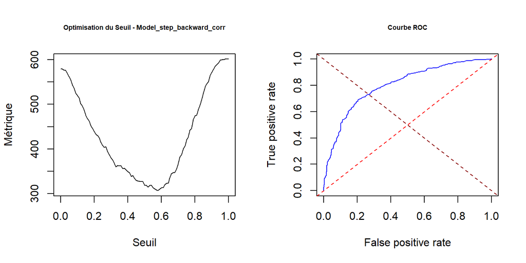

```r
par(mfrow = c(1, 2))
# Optimisation du seuil
seuils <- seq(0, 1, by = 0.01)
res_step_backward_corr <- rep(NA, length(seuils))

for (i in 1:length(seuils)) {
    pred_step_backward_corr <- (pred_prob_step_backward_corr >=
        seuils[i])
    res_step_backward_corr[i] <- sum(pred_step_backward_corr &
        (meteo_train$pluie.demain == "FALSE")) + sum(!pred_step_backward_corr &
        (meteo_train$pluie.demain == "TRUE"))
}

# Tracé du graph en fonction du seuil
plot(seuils, res_step_backward_corr, type = "l", main = "Optimisation du Seuil - Model_step_backward_corr",
    xlab = "Seuil", ylab = "Métrique", cex.main = 0.6)
best_seuil_step_backward_corr <- seuils[which.min(res_step_backward_corr)]
# cat('Meilleur seuil:', best_seuil_step_backward_corr,
# '\n')

cout = function(s) {
    pred_step_backward_corr <- (pred_prob_step_backward_corr >=
        s)
    # Coût = 1 * nombre de faux positifs + 1 * nombre de
    # faux négatifs
    1 * sum(pred_step_backward_corr & (meteo_train$pluie.demain ==
        "FALSE")) + 1 * sum(!pred_step_backward_corr & (meteo_train$pluie.demain ==
        "TRUE"))
}

cost_0_5_step_backward_corr <- cout(0.5)
# cat('Coût pour le seuil de 0.5:',
# cost_0_5_step_backward_corr, '\n')

# Calculer et afficher le coût pour le meilleur seuil
cost_best_seuil_step_backward_corr <- cout(best_seuil_step_backward_corr)
# cat('Coût pour le meilleur seuil:',
# cost_best_seuil_step_backward_corr, '\n')

# Calcul et tracé de la courbe ROC
pred_roc_step_backward_corr <- prediction(pred_prob_step_backward_corr,
    meteo_train$pluie.demain)
perf_step_backward_corr <- performance(pred_roc_step_backward_corr,
    "tpr", "fpr")
plot(perf_step_backward_corr, col = "blue", main = "Courbe ROC",
    cex.main = 0.6)
abline(0, 1, lty = 2, col = "red")  # Ligne de référence
abline(1, -1, lty = 2, col = "darkred")
```

```r
# Calcul de l'AUC
auc_step_backward_corr <- performance(pred_roc_step_backward_corr,
    "auc")
auc_value_step_backward_corr <- auc_step_backward_corr@y.values[[1]]
# cat('AUC - model_step_backward_corr:',
# auc_value_step_backward_corr, '\n')

results_step_backward_corr <- data.frame(Metric = c("Meilleur seuil",
    "Coût pour le seuil de 0.5", "Coût pour le meilleur seuil",
    "AUC - model_step_backward_corr"), Value = c(sprintf("%.2f",
    best_seuil_step_backward_corr), cost_0_5_step_backward_corr,
    cost_best_seuil_step_backward_corr, sprintf("%.2f", auc_value_step_backward_corr)))

kable(results_step_backward_corr, caption = "Seuil, Coût 0.5, Coût Seuil Optimal, AUC")
```

Seuil, Coût 0.5, Coût Seuil Optimal, AUC

| Metric | Value |
| --- | --- |
| Meilleur seuil | 0.58 |
| Coût pour le seuil de 0.5 | 319 |
| Coût pour le meilleur seuil | 307 |
| AUC - model_step_backward_corr | 0.80 |

## 3.2 Choix du modèle Probit

Nous allons étudier maintenant les modèles probit. Un modèle probit est un modèle de régression utilisé pour les variables dépendantes binaires. Il est principalement utilisé pour estimer la probabilité qu’un événement se produise. Le modèle probit se déinit comme suit $Y_i \sim \text{Bernoulli}(p_i)$ avec $p_i = \Phi(\beta_0 + \beta_1 x_i)$ où $\Phi$ est la fonction de répartition de la loi $\mathcal{N}(0, 1)$. Les modèles logit et probit donnent des résultats très proches. Nous allons ici étudier le model_initial puis un model_step provenant du model_inital version probit.

### 3.2.1 Modèle initial Probit

Nous commencerons par regarder un model_initial en fonction de lien probit, qui prend en compte toutes les variables encore présente dans “meteo_train”.

```r
model_initial_probit <- glm(pluie.demain ~ ., family = binomial(link = "probit"),
    data = meteo_train)
```

Ci dessous est présenté, le summary du model_initial_probit avec les coefficients et la significativité. Le modèle a atteint la convergence vers l’estimateur du maximum de vraisemblance après cinq itérations du scoring de Fisher.

Estimate

Std..Error

z.value

p.value

Significance

(Intercept)

-44.760

41.334

-1.083

0.279

Year

0.040

0.020

1.971

0.049

Month

-0.012

0.015

-0.857

0.391

Day

0.007

0.005

1.368

0.171

TempMean

0.114

0.095

1.203

0.229

HumidityMean

0.009

0.019

0.498

0.618

PressureMean

0.288

0.079

3.622

0.000

***

PrecipitationTotal

0.015

0.016

0.946

0.344

Snowfall

-0.170

0.129

-1.316

0.188

TotalCloudMean

0.007

0.007

1.050

0.294

HighCloudMean

-0.002

0.004

-0.408

0.683

MediumCloudMean

0.003

0.004

0.774

0.439

LowCloudMean

-0.003

0.005

-0.582

0.560

Sunshine

0.000

0.001

0.596

0.551

RadShortwave

0.000

0.000

0.294

0.769

WindSpeed10mMean

-0.031

0.057

-0.537

0.591

WindDir10mMean

0.003

0.003

1.003

0.316

WindSpeed80mMean

-0.056

0.041

-1.384

0.166

WindDir80mMean

-0.006

0.003

-1.644

0.100

WindSpeed900mbMean

0.012

0.015

0.821

0.412

WindDir900mbMean

0.003

0.001

3.702

0.000

***

WindGustMean

0.012

0.021

0.575

0.565

TempMax

-0.015

0.055

-0.271

0.787

TempMin

-0.075

0.050

-1.493

0.136

HumidityMax

0.001

0.012

0.080

0.936

HumidityMin

-0.002

0.011

-0.197

0.843

PressureMax

-0.146

0.043

-3.389

0.001

***

PressureMin

-0.180

0.043

-4.201

0.000

***

TotalCloudMax

0.002

0.003

0.576

0.565

TotalCloudMin

0.004

0.004

1.138

0.255

HighCloudMax

0.002

0.002

1.202

0.229

HighCloudMin

0.001

0.011

0.051

0.959

MediumCloudMax

0.004

0.002

2.066

0.039

MediumCloudMin

-0.002

0.005

-0.367

0.714

LowCloudMax

0.002

0.002

0.894

0.371

LowCloudMin

0.001

0.004

0.127

0.899

WindSpeed10mMax

0.036

0.020

1.760

0.078

.

WindSpeed10mMin

0.095

0.037

2.549

0.011

WindSpeed80mMax

0.001

0.017

0.081

0.935

WindSpeed80mMin

-0.030

0.025

-1.207

0.227

WindSpeed900mbMax

-0.008

0.007

-1.188

0.235

WindSpeed900mbMin

-0.004

0.011

-0.404

0.686

WindGustMax

0.013

0.010

1.330

0.183

WindGustMin

0.004

0.016

0.253

0.800

```r
model_initial_probit <- glm(pluie.demain ~ ., family = binomial(link = "probit"),
    data = meteo_train)

model_stats_initial_probit <- data.frame(Statistic = c("Null Deviance",
    "Residual Deviance", "Number of Fisher Scoring Iterations",
    "AIC"), Value = c(model_initial_probit$null.deviance, model_initial_probit$deviance,
    model_initial_probit$iter, AIC(model_initial_probit)), DF = c(model_initial_probit$df.null,
    model_initial_probit$df.residual, NA, NA))
kable(model_stats_initial_probit)
```

| Statistic | Value | DF |
| --- | --- | --- |
| Null Deviance | 1635.417 | 1179 |
| Residual Deviance | 1236.123 | 1136 |
| Number of Fisher Scoring Iterations | 5.000 | NA |
| AIC | 1324.123 | NA |

On remarque dans ce model_initial_probit que l’AIC est moins bon que dans le model_initial (1324 au lieu de 1320) ainsi que la résidual déviance (1236 au lieu de 1232).

```r
if (knitr::is_html_output()) {
    # Vérification de la colinéarité
    vif(model_initial_probit)
}
```

```
##               Year              Month                Day           TempMean
##           1.379032           1.397519           1.037914         251.150828
##       HumidityMean       PressureMean PrecipitationTotal           Snowfall
##          19.470906         191.213879           2.060255           1.354677
##     TotalCloudMean      HighCloudMean    MediumCloudMean       LowCloudMean
##          27.647537           4.237897           7.523151          12.729726
##           Sunshine       RadShortwave   WindSpeed10mMean     WindDir10mMean
##          12.189832           9.418785          61.429843          25.779524
##   WindSpeed80mMean     WindDir80mMean WindSpeed900mbMean   WindDir900mbMean
##          53.370822          28.181152          30.334494           2.308849
##       WindGustMean            TempMax            TempMin        HumidityMax
##          24.606719         105.029056          58.216541           4.972356
##        HumidityMin        PressureMax        PressureMin      TotalCloudMax
##          10.683386          53.179967          61.496374           3.310138
##      TotalCloudMin       HighCloudMax       HighCloudMin     MediumCloudMax
##           3.659123           3.157018           1.470386           3.471705
##     MediumCloudMin        LowCloudMax        LowCloudMin    WindSpeed10mMax
##           1.702229           3.358519           2.585471          17.852852
##    WindSpeed10mMin    WindSpeed80mMax    WindSpeed80mMin  WindSpeed900mbMax
##          10.170497          16.340759          10.392337          13.006845
##  WindSpeed900mbMin        WindGustMax        WindGustMin
##           9.198179          11.128189           6.837435
```

```r
if (knitr::is_html_output()) {
    # Impact sur la deviance
    anova(model_initial_probit, test = "LRT")
}
```

```
## Analysis of Deviance Table
##
## Model: binomial, link: probit
##
## Response: pluie.demain
##
## Terms added sequentially (first to last)
##
##
##                    Df Deviance Resid. Df Resid. Dev  Pr(>Chi)
## NULL                                1179     1635.4
## Year                1    5.157      1178     1630.3 0.0231586 *
## Month               1    1.825      1177     1628.4 0.1767584
## Day                 1    0.065      1176     1628.4 0.7987035
## TempMean            1   19.774      1175     1608.6 8.718e-06 ***
## HumidityMean        1   16.472      1174     1592.1 4.936e-05 ***
## PressureMean        1  156.564      1173     1435.6 < 2.2e-16 ***
## PrecipitationTotal  1   20.671      1172     1414.9 5.453e-06 ***
## Snowfall            1    3.496      1171     1411.4 0.0615247 .
## TotalCloudMean      1   52.185      1170     1359.2 5.050e-13 ***
## HighCloudMean       1    7.014      1169     1352.2 0.0080870 **
## MediumCloudMean     1    5.755      1168     1346.4 0.0164386 *
## LowCloudMean        1    0.746      1167     1345.7 0.3876726
## Sunshine            1    1.093      1166     1344.6 0.2957290
## RadShortwave        1    0.087      1165     1344.5 0.7681212
## WindSpeed10mMean    1   11.602      1164     1332.9 0.0006589 ***
## WindDir10mMean      1    0.021      1163     1332.9 0.8857808
## WindSpeed80mMean    1    3.851      1162     1329.0 0.0497185 *
## WindDir80mMean      1    0.069      1161     1329.0 0.7930553
## WindSpeed900mbMean  1    2.510      1160     1326.5 0.1131159
## WindDir900mbMean    1   18.015      1159     1308.5 2.191e-05 ***
## WindGustMean        1    2.923      1158     1305.5 0.0873399 .
## TempMax             1    4.809      1157     1300.7 0.0283144 *
## TempMin             1    0.769      1156     1299.9 0.3805774
## HumidityMax         1    0.062      1155     1299.9 0.8034349
## HumidityMin         1    0.560      1154     1299.3 0.4542564
## PressureMax         1    0.208      1153     1299.1 0.6479850
## PressureMin         1   23.513      1152     1275.6 1.241e-06 ***
## TotalCloudMax       1    9.108      1151     1266.5 0.0025444 **
## TotalCloudMin       1    1.594      1150     1264.9 0.2067356
## HighCloudMax        1    6.199      1149     1258.7 0.0127856 *
## HighCloudMin        1    0.000      1148     1258.7 0.9938413
## MediumCloudMax      1    4.742      1147     1254.0 0.0294360 *
## MediumCloudMin      1    0.221      1146     1253.7 0.6383242
## LowCloudMax         1    1.062      1145     1252.7 0.3028653
## LowCloudMin         1    0.022      1144     1252.7 0.8832164
## WindSpeed10mMax     1    5.077      1143     1247.6 0.0242484 *
## WindSpeed10mMin     1    6.875      1142     1240.7 0.0087417 **
## WindSpeed80mMax     1    0.455      1141     1240.2 0.4999219
## WindSpeed80mMin     1    1.628      1140     1238.6 0.2020166
## WindSpeed900mbMax   1    0.563      1139     1238.1 0.4530807
## WindSpeed900mbMin   1    0.129      1138     1237.9 0.7198562
## WindGustMax         1    1.742      1137     1236.2 0.1868407
## WindGustMin         1    0.063      1136     1236.1 0.8021941
## ---
## Signif. codes:  0 '***' 0.001 '**' 0.01 '*' 0.05 '.' 0.1 ' ' 1
```

- Table deviance: Nous utiliserons tout d’abord, la fonction anova(model_initial_probit, test = “LRT”) présentée dans la version html du report. Dans le model_initial_probit, 18 variables réduisent la deviance du le modèle. Ces variables apportent une contribution significative et utile à la prédiction de la variable réponse. Parmi les plus significatives on retrouve les variables: “PressureMin”, “PressureMean”, “PrecipitationTotal”, “TotalCloudMean”, “WindDir900mbMean”, “HumidityMean”, “WindSpeed10mMean”, “TempMean”.
- Test de deviance: Nous utiliserons ensuite un test de deviance pour comparer notre modèle noté génériquement $M_k$ dans un premier temps à un modèle null $M_0$. Nous ferons ensuite des tests du $\chi^2$ de rapport de vraisemblance.

```r
pvalMoMkiniprobit <- pchisq(1635.4 - 1236.123, 1179 - 1136, lower = F)
cat("La p-valeur pour la différence de déviance est :", format(pvalMoMkiniprobit,
    scientific = TRUE))
```

```
## La p-valeur pour la différence de déviance est : 2.852602e-59
```

```r
pvalMkMsatiniprobit <- pchisq(1236.123, 1136, lower = F)
cat("La p-valeur est:", sprintf("%.3f", pvalMkMsatiniprobit))
```

```
## La p-valeur est: 0.020
```

On testera ensuite $M_k$ contre $M_{sat}$. La déviance résiduelle du model_inital_probit est de 1236.123 pour 1136 degrés de liberté. On remarquera que la p-valeur est de 0.02 et est toujours inférieure à 0.05. On rejette donc notre model_inital_probit car on lui préfère le modèle saturé. Notre modèle n’est pas encore suffisant et a p-valeur moins important que le model_initial

- Prédiction: Malgré le fait que le model_inital_probit soit rejeté, nous allons tout de même calculer les prédictions pour ce modèle pour pouvoir comparer avec les autre modèle. Voici la table de décision ci-dessous avec un seuil de décision fixé à 0.5 pour comparer les modèles. Nous avons des FPR (False Positive Rate) = $P(\tilde{Y} = 1 \mid Y = 0)$ = 161/579 = 27%, un spécificité 418/579 = 0.72 = 1-FPR et sensitivité TPR (True Positive Rate) = $P(\tilde{Y} = 1 \mid Y = 1)$ = 464/601 = 77%. En tout le model_inital_probit donne 74.75% de bonnes prédictions. Ce modèle donne des prédictions moins bonnes que le model_initial.

```r
pred_prob_initial_probit = predict(model_initial_probit, newdata = meteo_train,
    type = "response")
pred_initial_probit = (pred_prob_initial_probit >= 0.5)
table_initial_probit <- table(pred_initial_probit, meteo_train$pluie.demain)
table_initial_probit_print <- as.data.frame.matrix(table_initial_probit)
kable(table_initial_probit_print, caption = "Table de Décision - Model_initial_probit")
```

Table de Décision - Model_initial_probit

|  | FALSE | TRUE |
| --- | --- | --- |
| FALSE | 418 | 137 |
| TRUE | 161 | 464 |

```r
accuracy_model_initial_probit <- (mean(pred_initial_probit ==
    (meteo_train$pluie.demain == "TRUE"))) * 100
cat("Bonnes prédictions:", sprintf("%.2f%%", accuracy_model_initial_probit))
```

```
## Bonnes prédictions: 74.75%
```

Nous pouvons aussi peut définir un seuil $s$ optimal. Le seuil optimal reste donc proche de 0.5 et est de 0.51. 2 fausses prédictions sont enlevées. Nous avons aussi calculé la courbe ROC (receiving operator characteristic) avec en abscisse les FPR et en ordonnée les TPR. On voit que la courbe est au dessus de la droite d’équation $y=x$, notre modele_initial_probit fait donc mieux que l’aléatoire et l’AUC (Area Under Curve) qui mesure la qualité de la classification est de 82%, ce qui est un très bon score puisqu’il est au-dessous de la classification aléatoire (AUC=50%). L’AUC est égale au model_initial.

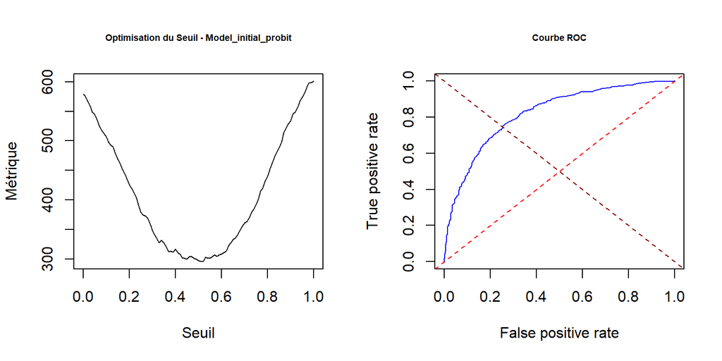

```r
par(mfrow = c(1, 2))
# Optimisation du seuil
seuils <- seq(0, 1, by = 0.01)
res_initial_probit <- rep(NA, length(seuils))

for (i in 1:length(seuils)) {
    pred_initial_probit <- (pred_prob_initial_probit >= seuils[i])
    res_initial_probit[i] <- sum(pred_initial_probit & (meteo_train$pluie.demain ==
        "FALSE")) + sum(!pred_initial_probit & (meteo_train$pluie.demain ==
        "TRUE"))
}

# Tracé du graph en fonction du seuil
plot(seuils, res_initial_probit, type = "l", main = "Optimisation du Seuil - Model_initial_probit",
    xlab = "Seuil", ylab = "Métrique", cex.main = 0.6)
best_seuil_initial_probit <- seuils[which.min(res_initial_probit)]
# cat('Meilleur seuil:', best_seuil_initial_probit, '\n')

cout = function(s) {
    pred_initial_probit <- (pred_prob_initial_probit >= s)
    # Coût = 1 * nombre de faux positifs + 1 * nombre de
    # faux négatifs
    1 * sum(pred_initial_probit & (meteo_train$pluie.demain ==
        "FALSE")) + 1 * sum(!pred_initial_probit & (meteo_train$pluie.demain ==
        "TRUE"))
}

cost_0_5_initial_probit <- cout(0.5)
# cat('Coût pour le seuil de 0.5:',
# cost_0_5_initial_probit, '\n')

# Calculer et afficher le coût pour le meilleur seuil
cost_best_seuil_initial_probit <- cout(best_seuil_initial_probit)
# cat('Coût pour le meilleur seuil:',
# cost_best_seuil_initial_probit, '\n')

# Calcul et tracé de la courbe ROC
pred_roc_initial_probit <- prediction(pred_prob_initial_probit,
    meteo_train$pluie.demain)
perf_initial_probit <- performance(pred_roc_initial_probit, "tpr",
    "fpr")
plot(perf_initial_probit, col = "blue", main = "Courbe ROC",
    cex.main = 0.6)
abline(0, 1, lty = 2, col = "red")  # Ligne de référence
abline(1, -1, lty = 2, col = "darkred")
```

```r
# Calcul de l'AUC
auc_initial_probit <- performance(pred_roc_initial_probit, "auc")
auc_value_initial_probit <- auc_initial_probit@y.values[[1]]
# cat('AUC - model_initial_probit:',
# auc_value_initial_probit, '\n')

results_initial_probit <- data.frame(Metric = c("Meilleur seuil",
    "Coût pour le seuil de 0.5", "Coût pour le meilleur seuil",
    "AUC - model_initial_probit"), Value = c(sprintf("%.2f",
    best_seuil_initial_probit), cost_0_5_initial_probit, cost_best_seuil_initial_probit,
    sprintf("%.2f", auc_value_initial_probit)))

kable(results_initial_probit, caption = "Seuil, Coût 0.5, Coût Seuil Optimal, AUC")
```

Seuil, Coût 0.5, Coût Seuil Optimal, AUC

| Metric | Value |
| --- | --- |
| Meilleur seuil | 0.51 |
| Coût pour le seuil de 0.5 | 298 |
| Coût pour le meilleur seuil | 296 |
| AUC - model_initial_probit | 0.82 |

### 3.2.2 Modèle initial Step Probit

Nous continuerons par regarder un model_step en fonction de lien probit pour exclure certaines variables du modèle model_initial_probit.

```r
if (knitr::is_html_output()) {
    model_step_prob <- step(model_initial_probit)
}
```

```
## Start:  AIC=1324.12
## pluie.demain ~ Year + Month + Day + TempMean + HumidityMean +
##     PressureMean + PrecipitationTotal + Snowfall + TotalCloudMean +
##     HighCloudMean + MediumCloudMean + LowCloudMean + Sunshine +
##     RadShortwave + WindSpeed10mMean + WindDir10mMean + WindSpeed80mMean +
##     WindDir80mMean + WindSpeed900mbMean + WindDir900mbMean +
##     WindGustMean + TempMax + TempMin + HumidityMax + HumidityMin +
##     PressureMax + PressureMin + TotalCloudMax + TotalCloudMin +
##     HighCloudMax + HighCloudMin + MediumCloudMax + MediumCloudMin +
##     LowCloudMax + LowCloudMin + WindSpeed10mMax + WindSpeed10mMin +
##     WindSpeed80mMax + WindSpeed80mMin + WindSpeed900mbMax + WindSpeed900mbMin +
##     WindGustMax + WindGustMin
##
##                      Df Deviance    AIC
## - HighCloudMin        1   1236.1 1322.1
## - HumidityMax         1   1236.1 1322.1
## - WindSpeed80mMax     1   1236.1 1322.1
## - LowCloudMin         1   1236.1 1322.1
## - HumidityMin         1   1236.2 1322.2
## - WindGustMin         1   1236.2 1322.2
## - TempMax             1   1236.2 1322.2
## - RadShortwave        1   1236.2 1322.2
## - MediumCloudMin      1   1236.2 1322.2
## - WindSpeed900mbMin   1   1236.3 1322.3
## - HighCloudMean       1   1236.3 1322.3
## - HumidityMean        1   1236.4 1322.4
## - WindSpeed10mMean    1   1236.4 1322.4
## - TotalCloudMax       1   1236.5 1322.5
## - WindGustMean        1   1236.5 1322.5
## - LowCloudMean        1   1236.5 1322.5
## - Sunshine            1   1236.5 1322.5
## - MediumCloudMean     1   1236.7 1322.7
## - WindSpeed900mbMean  1   1236.8 1322.8
## - Month               1   1236.9 1322.9
## - LowCloudMax         1   1236.9 1322.9
## - PrecipitationTotal  1   1237.0 1323.0
## - WindDir10mMean      1   1237.1 1323.1
## - TotalCloudMean      1   1237.2 1323.2
## - TotalCloudMin       1   1237.5 1323.5
## - WindSpeed900mbMax   1   1237.5 1323.5
```

[output cut: 1071 more lines]

```
## - TotalCloudMean    1   1251.6 1287.6
## - TotalCloudMin     1   1252.6 1288.6
## - TempMin           1   1252.8 1288.8
## - WindGustMax       1   1253.5 1289.5
## - Year              1   1253.6 1289.6
## - WindDir80mMean    1   1254.0 1290.0
## - WindSpeed10mMax   1   1255.5 1291.5
## - WindSpeed10mMin   1   1257.3 1293.3
## - TempMean          1   1257.4 1293.4
## - MediumCloudMax    1   1259.2 1295.2
## - PressureMax       1   1260.0 1296.0
## - WindDir900mbMean  1   1261.3 1297.3
## - PressureMean      1   1261.9 1297.9
## - WindSpeed80mMean  1   1262.7 1298.7
## - PressureMin       1   1268.0 1304.0
```

Le modèle probit donné par la fonction step est le suivant:

```r
model_step_probit <- glm(pluie.demain ~ Year + TempMean + PressureMean +
    Snowfall + TotalCloudMean + WindSpeed80mMean + WindDir80mMean +
    WindDir900mbMean + TempMin + PressureMax + PressureMin +
    TotalCloudMin + HighCloudMax + MediumCloudMax + LowCloudMax +
    WindSpeed10mMax + WindSpeed10mMin + WindGustMax, family = binomial(link = "probit"),
    data = meteo_train)
```

Ci dessous est présenté, le summary du model_step_probit avec les coefficients et la significativité. Le modèle a atteint la convergence vers l’estimateur du maximum de vraisemblance après cinq itérations du scoring de Fisher.

Estimate

Std..Error

z.value

p.value

Significance

(Intercept)

-41.803

36.929

-1.132

0.258

Year

0.040

0.018

2.208

0.027

TempMean

0.093

0.032

2.941

0.003

PressureMean

0.259

0.074

3.483

0.000

***

Snowfall

-0.170

0.119

-1.428

0.153

TotalCloudMean

0.004

0.003

1.701

0.089

.

WindSpeed80mMean

-0.066

0.018

-3.742

0.000

***

WindDir80mMean

-0.002

0.001

-2.297

0.022

WindDir900mbMean

0.003

0.001

3.530

0.000

***

TempMin

-0.068

0.034

-2.023

0.043

PressureMax

-0.134

0.041

-3.305

0.001

***

PressureMin

-0.165

0.040

-4.089

0.000

***

TotalCloudMin

0.005

0.002

1.953

0.051

.

HighCloudMax

0.002

0.001

1.553

0.120

MediumCloudMax

0.005

0.001

3.237

0.001

LowCloudMax

0.002

0.002

1.561

0.119

WindSpeed10mMax

0.035

0.013

2.623

0.009

WindSpeed10mMin

0.061

0.021

2.906

0.004

WindGustMax

0.014

0.006

2.200

0.028

```r
model_step_probit <- glm(pluie.demain ~ Year + TempMean + PressureMean +
    Snowfall + TotalCloudMean + WindSpeed80mMean + WindDir80mMean +
    WindDir900mbMean + TempMin + PressureMax + PressureMin +
    TotalCloudMin + HighCloudMax + MediumCloudMax + LowCloudMax +
    WindSpeed10mMax + WindSpeed10mMin + WindGustMax, family = binomial(link = "probit"),
    data = meteo_train)

model_stats_step_probit <- data.frame(Statistic = c("Null Deviance",
    "Residual Deviance", "Number of Fisher Scoring Iterations",
    "AIC"), Value = c(model_step_probit$null.deviance, model_step_probit$deviance,
    model_step_probit$iter, AIC(model_step_probit)), DF = c(model_step_probit$df.null,
    model_step_probit$df.residual, NA, NA))
kable(model_stats_step_probit)
```

| Statistic | Value | DF |
| --- | --- | --- |
| Null Deviance | 1635.417 | 1179 |
| Residual Deviance | 1248.701 | 1161 |
| Number of Fisher Scoring Iterations | 5.000 | NA |
| AIC | 1286.701 | NA |

On remarque que le model_step_probit est différent du model_step_backward en termes de variables. L’AIC reste tout de même l’un des meilleurs parmi les modèles avec 1286.

```r
if (knitr::is_html_output()) {
    # Vérification de la colinéarité
    vif(model_step_probit)
}
```

```
##             Year         TempMean     PressureMean         Snowfall
##         1.098084        28.362461       169.308478         1.155392
##   TotalCloudMean WindSpeed80mMean   WindDir80mMean WindDir900mbMean
##         3.943523        10.087872         1.919020         1.839968
##          TempMin      PressureMax      PressureMin    TotalCloudMin
##        26.176410        47.668852        54.936304         1.575585
##     HighCloudMax   MediumCloudMax      LowCloudMax  WindSpeed10mMax
##         1.816852         2.238610         2.007733         7.800844
##  WindSpeed10mMin      WindGustMax
##         3.251570         4.434102
```

- Colinéarité : En utilisant la fonction VIF nous avons parmi les vif les plus importants “PressureMean avec un vif de 169. Ce modèle a toujours de nombreuses colinéarité en probit sur les variables”Pressure” et “Temp”. Il faudrait retirer ses variables ou leurs variables corrélées.

```r
if (knitr::is_html_output()) {
    # Impact sur la deviance
    anova(model_step_probit, test = "LRT")
    anova(model_initial_probit, model_step_probit, test = "LRT")
}
```

```
## Analysis of Deviance Table
##
## Model 1: pluie.demain ~ Year + Month + Day + TempMean + HumidityMean +
##     PressureMean + PrecipitationTotal + Snowfall + TotalCloudMean +
##     HighCloudMean + MediumCloudMean + LowCloudMean + Sunshine +
##     RadShortwave + WindSpeed10mMean + WindDir10mMean + WindSpeed80mMean +
##     WindDir80mMean + WindSpeed900mbMean + WindDir900mbMean +
##     WindGustMean + TempMax + TempMin + HumidityMax + HumidityMin +
##     PressureMax + PressureMin + TotalCloudMax + TotalCloudMin +
##     HighCloudMax + HighCloudMin + MediumCloudMax + MediumCloudMin +
##     LowCloudMax + LowCloudMin + WindSpeed10mMax + WindSpeed10mMin +
##     WindSpeed80mMax + WindSpeed80mMin + WindSpeed900mbMax + WindSpeed900mbMin +
##     WindGustMax + WindGustMin
## Model 2: pluie.demain ~ Year + TempMean + PressureMean + Snowfall + TotalCloudMean +
##     WindSpeed80mMean + WindDir80mMean + WindDir900mbMean + TempMin +
##     PressureMax + PressureMin + TotalCloudMin + HighCloudMax +
##     MediumCloudMax + LowCloudMax + WindSpeed10mMax + WindSpeed10mMin +
##     WindGustMax
##   Resid. Df Resid. Dev  Df Deviance Pr(>Chi)
## 1      1136     1236.1
## 2      1161     1248.7 -25  -12.578   0.9813
```

- Table deviance: Nous utiliserons tout d’abord, la fonction anova(model_step_probit, test = “LRT”) présentée dans la version html du report. Dans le model_step_probit, 14 variables réduisent la deviance du le modèle. Ces variables apportent une contribution significative et utile à la prédiction de la variable réponse. Parmi les plus significatives on retrouve les variables: “PressureMin”, “PressureMean”, “TotalCloudMean”, “WindDir900mbMean”, “WindSpeed10mMax”, “TempMean”, “MediumCloudMax”, “HighCloudMax”, “WindSpeed80mMean”. Ensuite nous utiliserons la fonction anova(model_initial_probit, model_step_probit, test = “LRT”). La p-valeur est égale à 0.9813 et nous remarquons que la différence entre les deux modèles n’est pas statistiquement significative. On pourra préférer le model_step_probit car il a moins de variables.
- Test de deviance: Nous utiliserons ensuite un test de deviance pour comparer notre modèle noté génériquement $M_k$ dans un premier temps à un modèle null $M_0$. Nous ferons ensuite des tests du $\chi^2$ de rapport de vraisemblance.

```r
pvalMoMkstepprobit <- pchisq(1635.4 - 1248.701, 1179 - 1161,
    lower = F)
cat("La p-valeur pour la différence de déviance est :", format(pvalMoMkstepprobit,
    scientific = TRUE))
```

```
## La p-valeur pour la différence de déviance est : 5.405733e-71
```

```r
pvalMkMsatstepprobit <- pchisq(1248.701, 1161, lower = F)
cat("La p-valeur est:", sprintf("%.3f", pvalMkMsatstepprobit))
```

```
## La p-valeur est: 0.037
```

- Prédiction: Malgré le fait que le model_step_probit soit rejeté, nous allons tout de même calculer les prédictions pour ce modèle pour pouvoir comparer avec les autre modèle. Voici la table de décision ci-dessous avec un seuil de décision fixé à 0.5 pour comparer les modèles. Nous avons des FPR (False Positive Rate) = $P(\tilde{Y} = 1 \mid Y = 0)$ = 167/579 = 29%, un spécificité 412/579 = 0.71 = 1-FPR et sensitivité TPR (True Positive Rate) = $P(\tilde{Y} = 1 \mid Y = 1)$ = 465/601 = 77%. En tout le model_step_probit donne 74.32% de bonnes prédictions. Ce modèle donne des prédictions un peu moins bonnes que le model_initial_probit et le model_step_backward.

```r
pred_prob_step_probit = predict(model_step_probit, newdata = meteo_train,
    type = "response")
pred_step_probit = (pred_prob_step_probit >= 0.5)
table_step_probit <- table(pred_step_probit, meteo_train$pluie.demain)
table_step_probit_print <- as.data.frame.matrix(table_step_probit)
kable(table_step_probit_print, caption = "Table de Décision - Model_step_probit")
```

Table de Décision - Model_step_probit

|  | FALSE | TRUE |
| --- | --- | --- |
| FALSE | 412 | 136 |
| TRUE | 167 | 465 |

```r
accuracy_model_step_probit <- (mean(pred_step_probit == (meteo_train$pluie.demain ==
    "TRUE"))) * 100
cat("Bonnes prédictions:", sprintf("%.2f%%", accuracy_model_step_probit))
```

```
## Bonnes prédictions: 74.32%
```

Nous pouvons aussi peut définir un seuil $s$ optimal. Le seuil optimal reste donc proche de 0.5 et est de 0.46. 8 fausses prédictions sont enlevées. Nous avons aussi calculé la courbe ROC (receiving operator characteristic) avec en abscisse les FPR et en ordonnée les TPR. On voit que la courbe est au dessus de la droite d’équation $y=x$, notre modele_step_probit fait donc mieux que l’aléatoire et l’AUC (Area Under Curve) qui mesure la qualité de la classification est de 82%, ce qui est un très bon score puisqu’il est au-dessous de la classification aléatoire (AUC=50%). L’AUC est égale au model_initial_probit.

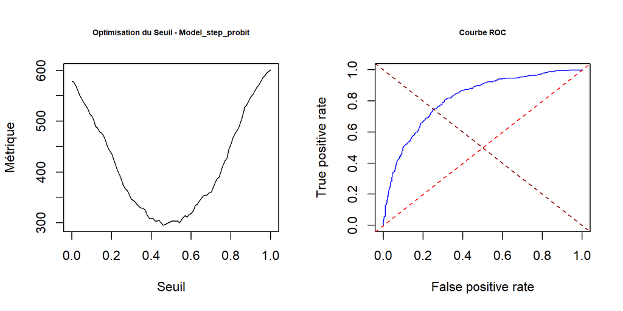

```r
par(mfrow = c(1, 2))
# Optimisation du seuil
seuils <- seq(0, 1, by = 0.01)
res_step_probit <- rep(NA, length(seuils))

for (i in 1:length(seuils)) {
    pred_step_probit <- (pred_prob_step_probit >= seuils[i])
    res_step_probit[i] <- sum(pred_step_probit & (meteo_train$pluie.demain ==
        "FALSE")) + sum(!pred_step_probit & (meteo_train$pluie.demain ==
        "TRUE"))
}

# Tracé du graph en fonction du seuil
plot(seuils, res_step_probit, type = "l", main = "Optimisation du Seuil - Model_step_probit",
    xlab = "Seuil", ylab = "Métrique", cex.main = 0.6)
best_seuil_step_probit <- seuils[which.min(res_step_probit)]
# cat('Meilleur seuil:', best_seuil_step_probit, '\n')

cout = function(s) {
    pred_step_probit <- (pred_prob_step_probit >= s)
    # Coût = 1 * nombre de faux positifs + 1 * nombre de
    # faux négatifs
    1 * sum(pred_step_probit & (meteo_train$pluie.demain == "FALSE")) +
        1 * sum(!pred_step_probit & (meteo_train$pluie.demain ==
            "TRUE"))
}

cost_0_5_step_probit <- cout(0.5)
# cat('Coût pour le seuil de 0.5:', cost_0_5_step_probit,
# '\n')

# Calculer et afficher le coût pour le meilleur seuil
cost_best_seuil_step_probit <- cout(best_seuil_step_probit)
# cat('Coût pour le meilleur seuil:',
# cost_best_seuil_step_probit, '\n')

# Calcul et tracé de la courbe ROC
pred_roc_step_probit <- prediction(pred_prob_step_probit, meteo_train$pluie.demain)
perf_step_probit <- performance(pred_roc_step_probit, "tpr",
    "fpr")
plot(perf_step_probit, col = "blue", main = "Courbe ROC", cex.main = 0.6)
abline(0, 1, lty = 2, col = "red")  # Ligne de référence
abline(1, -1, lty = 2, col = "darkred")
```

```r
# Calcul de l'AUC
auc_step_probit <- performance(pred_roc_step_probit, "auc")
auc_value_step_probit <- auc_step_probit@y.values[[1]]
# cat('AUC - model_step_probit:', auc_value_step_probit,
# '\n')

results_step_probit <- data.frame(Metric = c("Meilleur seuil",
    "Coût pour le seuil de 0.5", "Coût pour le meilleur seuil",
    "AUC - model_step_probit"), Value = c(sprintf("%.2f", best_seuil_step_probit),
    cost_0_5_step_probit, cost_best_seuil_step_probit, sprintf("%.2f",
        auc_value_step_probit)))

kable(results_step_probit, caption = "Seuil, Coût 0.5, Coût Seuil Optimal, AUC")
```

Seuil, Coût 0.5, Coût Seuil Optimal, AUC

| Metric | Value |
| --- | --- |
| Meilleur seuil | 0.46 |
| Coût pour le seuil de 0.5 | 303 |
| Coût pour le meilleur seuil | 295 |
| AUC - model_step_probit | 0.82 |

# 4. Cross Validation des modèles

Pour faire la cross validation des modèles nous choisirons, la cross validation k-fold qui est une méthode de validation des modèles qui permet de mieux estimer la performance d’un modèle en utilisant des échantillons répétés de l’ensemble des données. Nous choissisons $k=10$ qui est le nombre de fold. Pour chaque fold $i$ de 1 à 10, on va entraîner le modèle, faire des prédictions sur le fold de test pour chaque modèle et ensuite calculer la proportion de bonnes prédictions (“Mean Accuracy”) et calculer l’erreur moyenne (“Mean Error”). Les résultats sont présentés ci-dessous:

```r
# k-fold 10 Validation croisée k-fold

k = 10
index = sample(1:k, nrow(meteo_train), replace = T)
res.model_initial = rep(NA, k)
res.model_manuel = rep(NA, k)
res.model_step_backward = rep(NA, k)
res.model_step_backward_corr = rep(NA, k)
res.model_initial_probit = rep(NA, k)
res.model_step_probit = rep(NA, k)
error.model_initial = rep(NA, k)
error.model_manuel = rep(NA, k)
error.model_step_backward = rep(NA, k)
error.model_step_backward_corr = rep(NA, k)
error.model_initial_probit = rep(NA, k)
error.model_step_probit = rep(NA, k)

for (i in 1:k) {
    reg.model_initial = glm(pluie.demain ~ ., family = binomial,
        data = meteo_train[index != i, ])

    reg.model_manuel = glm(pluie.demain ~ MediumCloudMax + HighCloudMax +
        TotalCloudMax + WindGustMax + TempMin + PressureMin +
        WindDir900mbMean + Sunshine + PrecipitationTotal, family = binomial,
        data = meteo_train[index != i, ])

    reg.model_step_backward = glm(pluie.demain ~ Year + TempMean +
        PressureMean + Snowfall + MediumCloudMean + WindSpeed80mMean +
        WindDir80mMean + WindDir900mbMean + TempMin + PressureMax +
        PressureMin + TotalCloudMax + TotalCloudMin + MediumCloudMax +
        WindSpeed10mMax + WindSpeed10mMin + WindGustMax, family = binomial,
        data = meteo_train[index != i, ])

    reg.model_step_backward_corr = glm(pluie.demain ~ Year +
        TempMean + PressureMean + Snowfall + MediumCloudMean +
        WindDir80mMean + WindDir900mbMean + TotalCloudMax + TotalCloudMin +
        MediumCloudMax + WindSpeed10mMax + WindSpeed10mMin +
        WindGustMax, family = binomial, data = meteo_train[index !=
        i, ])

    reg.model_initial_probit = glm(pluie.demain ~ ., family = binomial(link = "probit"),
        data = meteo_train[index != i, ])

    reg.model_step_probit = glm(pluie.demain ~ Year + TempMean +
        PressureMean + Snowfall + TotalCloudMean + WindSpeed80mMean +
        WindDir80mMean + WindDir900mbMean + TempMin + PressureMax +
        PressureMin + TotalCloudMin + HighCloudMax + MediumCloudMax +
        LowCloudMax + WindSpeed10mMax + WindSpeed10mMin + WindGustMax,
        family = binomial(link = "probit"), data = meteo_train[index !=
            i, ])

    pred.model_initial = predict(reg.model_initial, newdata = meteo_train[index ==
        i, ], type = "response")
    pred.model_manuel = predict(reg.model_manuel, newdata = meteo_train[index ==
        i, ], type = "response")

    pred.model_step_backward = predict(reg.model_step_backward,
        newdata = meteo_train[index == i, ], type = "response")

    pred.model_step_backward_corr = predict(reg.model_step_backward_corr,
        newdata = meteo_train[index == i, ], type = "response")

    pred.model_initial_probit = predict(reg.model_initial_probit,
        newdata = meteo_train[index == i, ], type = "response")

    pred.model_step_probit = predict(reg.model_step_probit, newdata = meteo_train[index ==
        i, ], type = "response")

    res.model_initial[i] = mean(meteo_train[index == i, "pluie.demain"] ==
        (pred.model_initial > 0.5), na.rm = T)
    res.model_manuel[i] = mean(meteo_train[index == i, "pluie.demain"] ==
        (pred.model_manuel > 0.5), na.rm = T)
    res.model_step_backward[i] = mean(meteo_train[index == i,
        "pluie.demain"] == (pred.model_step_backward > 0.5),
        na.rm = T)

    res.model_step_backward_corr[i] = mean(meteo_train[index ==
        i, "pluie.demain"] == (pred.model_step_backward_corr >
        0.5), na.rm = T)

    res.model_initial_probit[i] = mean(meteo_train[index == i,
        "pluie.demain"] == (pred.model_initial_probit > 0.5),
        na.rm = T)

    res.model_step_probit[i] = mean(meteo_train[index == i, "pluie.demain"] ==
        (pred.model_step_probit > 0.5), na.rm = T)

    error.model_initial[i] = mean(abs(pred.model_initial - as.numeric(meteo_train[index ==
        i, "pluie.demain"][[1]])), na.rm = TRUE)
    error.model_manuel[i] = mean(abs(pred.model_manuel - as.numeric(meteo_train[index ==
        i, "pluie.demain"][[1]])), na.rm = TRUE)

    error.model_step_backward[i] = mean(abs(pred.model_step_backward -
        as.numeric(meteo_train[index == i, "pluie.demain"][[1]])),
        na.rm = TRUE)

    error.model_step_backward_corr[i] = mean(abs(pred.model_step_backward_corr -
        as.numeric(meteo_train[index == i, "pluie.demain"][[1]])),
        na.rm = TRUE)

    error.model_initial_probit[i] = mean(abs(pred.model_initial_probit -
        as.numeric(meteo_train[index == i, "pluie.demain"][[1]])),
        na.rm = TRUE)

    error.model_step_probit[i] = mean(abs(pred.model_step_probit -
        as.numeric(meteo_train[index == i, "pluie.demain"][[1]])),
        na.rm = TRUE)
}

# Moyenne de la précision et de l'erreur 0-1
mean_accuracy_model_initial = mean(res.model_initial)
mean_accuracy_model_manuel = mean(res.model_manuel)
mean_accuracy_model_step_backward = mean(res.model_step_backward)
mean_accuracy_model_step_backward_corr = mean(res.model_step_backward_corr)
mean_accuracy_model_initial_probit = mean(res.model_initial_probit)
mean_accuracy_model_step_probit = mean(res.model_step_probit)

mean_error_model_initial = mean(error.model_initial)
mean_error_model_manuel = mean(error.model_manuel)
mean_error_model_step_backward = mean(error.model_step_backward)
mean_error_model_step_backward_corr = mean(error.model_step_backward_corr)
mean_error_model_initial_probit = mean(error.model_initial_probit)
mean_error_model_step_probit = mean(error.model_step_probit)

results_cross_validation <- data.frame(Model = c("model_initial",
    "model_manuel", "model_step_backward", "model_step_backward_corr",
    "model_initial_probit", "model_step_probit"), Mean_Accuracy = c(mean_accuracy_model_initial,
    mean_accuracy_model_manuel, mean_accuracy_model_step_backward,
    mean_accuracy_model_step_backward_corr, mean_accuracy_model_initial_probit,
    mean_accuracy_model_step_probit), Mean_Error = c(mean_error_model_initial,
    mean_error_model_manuel, mean_error_model_step_backward,
    mean_error_model_step_backward_corr, mean_error_model_initial_probit,
    mean_error_model_step_probit))

kable(results_cross_validation)
```

| Model | Mean_Accuracy | Mean_Error |
| --- | --- | --- |
| model_initial | 0.7158893 | 0.3648963 |
| model_manuel | 0.7215863 | 0.3773086 |
| model_step_backward | 0.7348024 | 0.3605772 |
| model_step_backward_corr | 0.7210916 | 0.3745471 |
| model_initial_probit | 0.7179672 | 0.3667623 |
| model_step_probit | 0.7299756 | 0.3627712 |

Nous pouvons constater qu’à chaque run le model_step_backward à l’erreur la plus petite et le pourcentage de bonnes prédictions le plus élevé pour tous les modèles évalués. On sélectionnera donc ce modèle pour faire nos prédictions sur nos données “meteo_test” malgré ses inconvénients.

# 5. Prédictions sur meteo_test

Nous commençons pas charger le fichier “meteo_test” en appliquant le même traitement que pour “meteo_train” sur la variable X. Nous allons également renommer les variables pour avoir les mêmes noms entres les deux fichiers.

```r
meteo_test <- read_csv("C:/Documents/Dauphine/Module 2/Modèle Linéaire Généralisé/Projet/meteo.test.csv",
    show_col_types = FALSE, name_repair = "minimal")
meteo_test <- meteo_test[, -1]
```

```r
if (knitr::is_html_output()) {
    summary(meteo_test)
}
```

```
##       Year          Month             Day             Hour       Minute
##  Min.   :2010   Min.   : 1.000   Min.   : 1.00   Min.   :0   Min.   :0
##  1st Qu.:2012   1st Qu.: 4.000   1st Qu.: 8.00   1st Qu.:0   1st Qu.:0
##  Median :2014   Median : 7.000   Median :16.00   Median :0   Median :0
##  Mean   :2014   Mean   : 6.859   Mean   :15.26   Mean   :0   Mean   :0
##  3rd Qu.:2016   3rd Qu.:10.000   3rd Qu.:22.00   3rd Qu.:0   3rd Qu.:0
##  Max.   :2018   Max.   :12.000   Max.   :31.00   Max.   :0   Max.   :0
##  Temperature.daily.mean..2.m.above.gnd.
##  Min.   :-5.040
##  1st Qu.: 5.625
##  Median :13.085
##  Mean   :12.062
##  3rd Qu.:18.170
##  Max.   :26.600
##  Relative.Humidity.daily.mean..2.m.above.gnd.
##  Min.   :36.42
##  1st Qu.:64.35
##  Median :71.64
##  Mean   :71.08
##  3rd Qu.:78.06
##  Max.   :91.46
##  Mean.Sea.Level.Pressure.daily.mean..MSL. Total.Precipitation.daily.sum..sfc.
##  Min.   : 983                             Min.   : 0.000
##  1st Qu.:1012                             1st Qu.: 0.000
##  Median :1017                             Median : 0.100
##  Mean   :1017                             Mean   : 2.202
##  3rd Qu.:1022                             3rd Qu.: 2.475
##  Max.   :1046                             Max.   :39.300
##  Snowfall.amount.raw.daily.sum..sfc. Total.Cloud.Cover.daily.mean..sfc.
##  Min.   :0.00000                     Min.   :  0.00
##  1st Qu.:0.00000                     1st Qu.: 30.20
##  Median :0.00000                     Median : 52.30
##  Mean   :0.08255                     Mean   : 53.62
##  3rd Qu.:0.00000                     3rd Qu.: 79.60
##  Max.   :6.65000                     Max.   :100.00
##  High.Cloud.Cover.daily.mean..high.cld.lay.
##  Min.   : 0.000
##  1st Qu.: 1.603
##  Median :12.210
##  Mean   :20.451
```

[output cut: 141 more lines]

```
##  Max.   :43.210                        Max.   :148.95
##  Wind.Speed.daily.min..900.mb. Wind.Gust.daily.max..sfc.
##  Min.   : 0.00                 Min.   :  5.76
##  1st Qu.: 3.34                 1st Qu.: 18.00
##  Median : 6.92                 Median : 26.64
##  Mean   :11.66                 Mean   : 30.30
##  3rd Qu.:15.58                 3rd Qu.: 38.43
##  Max.   :81.12                 Max.   :133.20
##  Wind.Gust.daily.min..sfc.
##  Min.   : 0.000
##  1st Qu.: 1.800
##  Median : 3.960
##  Mean   : 6.825
##  3rd Qu.: 8.190
##  Max.   :54.720
```

```r
meteo_test <- meteo_test %>%
    rename(Year = Year, Month = Month, Day = Day, Hour = Hour,
        Minute = Minute, TempMean = Temperature.daily.mean..2.m.above.gnd.,
        HumidityMean = Relative.Humidity.daily.mean..2.m.above.gnd.,
        PressureMean = Mean.Sea.Level.Pressure.daily.mean..MSL.,
        PrecipitationTotal = Total.Precipitation.daily.sum..sfc.,
        Snowfall = Snowfall.amount.raw.daily.sum..sfc., TotalCloudMean = Total.Cloud.Cover.daily.mean..sfc.,
        HighCloudMean = High.Cloud.Cover.daily.mean..high.cld.lay.,
        MediumCloudMean = Medium.Cloud.Cover.daily.mean..mid.cld.lay.,
        LowCloudMean = Low.Cloud.Cover.daily.mean..low.cld.lay.,
        Sunshine = Sunshine.Duration.daily.sum..sfc., RadShortwave = Shortwave.Radiation.daily.sum..sfc.,
        WindSpeed10mMean = Wind.Speed.daily.mean..10.m.above.gnd.,
        WindDir10mMean = Wind.Direction.daily.mean..10.m.above.gnd.,
        WindSpeed80mMean = Wind.Speed.daily.mean..80.m.above.gnd.,
        WindDir80mMean = Wind.Direction.daily.mean..80.m.above.gnd.,
        WindSpeed900mbMean = Wind.Speed.daily.mean..900.mb.,
        WindDir900mbMean = Wind.Direction.daily.mean..900.mb.,
        WindGustMean = Wind.Gust.daily.mean..sfc., TempMax = Temperature.daily.max..2.m.above.gnd.,
        TempMin = Temperature.daily.min..2.m.above.gnd., HumidityMax = Relative.Humidity.daily.max..2.m.above.gnd.,
        HumidityMin = Relative.Humidity.daily.min..2.m.above.gnd.,
        PressureMax = Mean.Sea.Level.Pressure.daily.max..MSL.,
        PressureMin = Mean.Sea.Level.Pressure.daily.min..MSL.,
        TotalCloudMax = Total.Cloud.Cover.daily.max..sfc., TotalCloudMin = Total.Cloud.Cover.daily.min..sfc.,
        HighCloudMax = High.Cloud.Cover.daily.max..high.cld.lay.,
        HighCloudMin = High.Cloud.Cover.daily.min..high.cld.lay.,
        MediumCloudMax = Medium.Cloud.Cover.daily.max..mid.cld.lay.,
        MediumCloudMin = Medium.Cloud.Cover.daily.min..mid.cld.lay.,
        LowCloudMax = Low.Cloud.Cover.daily.max..low.cld.lay.,
        LowCloudMin = Low.Cloud.Cover.daily.min..low.cld.lay.,
        WindSpeed10mMax = Wind.Speed.daily.max..10.m.above.gnd.,
        WindSpeed10mMin = Wind.Speed.daily.min..10.m.above.gnd.,
        WindSpeed80mMax = Wind.Speed.daily.max..80.m.above.gnd.,
        WindSpeed80mMin = Wind.Speed.daily.min..80.m.above.gnd.,
        WindSpeed900mbMax = Wind.Speed.daily.max..900.mb., WindSpeed900mbMin = Wind.Speed.daily.min..900.mb.,
        WindGustMax = Wind.Gust.daily.max..sfc., WindGustMin = Wind.Gust.daily.min..sfc.,
        )
```

En regardant le summary de “meteo_test” on s’aperçoit que les variables “Hour” et “Minute” sont semblables à celles de “meteo_train” avec une valeur constante à 0. Nous allons donc aussi exclure ces variables.

```r
# Exclusion des variables 'Hour' et 'Minute' de meteo_train
meteo_test <- meteo_test %>%
    dplyr::select(-Hour, -Minute)
```

Nous continuerons en effectuant les prédictions avec le modèle sélectionné: model_step_backward.

```r
pred_test = predict(model_step_backward, meteo_test, type = "response")
pluie.demain = (pred_test >= 0.5)
```

Nous allons ensuite imprimer nos résultats dans la table “meteo_test” et sortir un fichier de prédictions nommé : “Prediction_Sophie_ROBERT_OKADA.csv”.

```r
predpluie <- cbind(meteo_test, pluie.demain)
View(predpluie)
write.table(predpluie, "Prediction_Sophie_ROBERT_OKADA.csv",
    sep = ";", col.names = TRUE)
```

# 6. Conclusion du Projet

Après une longue recherche sur le meilleur modèle, il n’a pas été simple de choisir parmi les modèles considérés. Le model_step_backward semble être le meilleur parmi ceux testés, mais il présente des défauts. Il aurait peut-être été judicieux de considérer le model_manuel, plus simple, bien que ses prédictions soient moins précises et que son erreur soit plus importante. Cela aurait également permis de réduire les risques d’overfitting.

En conclusion, la prévision météorologique reste une tâche complexe en raison des interactions multiples entre les variables. Pour analyser ces variables, une analyse en composantes principales (ACP) aurait pu être plus pertinente dans le contexte de la prévision météorologique car cela nous aurait permis de réduire la dimensionnalité et d’améliorer la performance en réduisant la complexité du modèle.

# 7. Bibliographie

- Cours Robin RYDER - Modèles Linéaires Généralisés
- Cours Vincent Rivoiard - Choix de Modèles

# 8. Annexes

## 8.1 Annexe 1 - Summary des données

### Summary Meteo_Train

**meteo_train**  
**Dimensions:** 1180 x 44  
**Duplicates:** 0

| No | Variable | Stats / Values | Freqs (% of Valid) | Graph | Missing |
| --- | --- | --- | --- | --- | --- |
| 1 | Year [numeric] | Mean (sd) : 2013.9 (2.4) min < med < max: 2010 < 2014 < 2018 IQR (CV) : 4 (0) | 2010 : 86 ( 7.3%) 2011 : 153 (13.0%) 2012 : 149 (12.6%) 2013 : 144 (12.2%) 2014 : 147 (12.5%) 2015 : 143 (12.1%) 2016 : 143 (12.1%) 2017 : 143 (12.1%) 2018 : 72 ( 6.1%) |  | 0 (0.0%) |
| 2 | Month [numeric] | Mean (sd) : 6.4 (3.4) min < med < max: 1 < 6 < 12 IQR (CV) : 6 (0.5) | 12 distinct values |  | 0 (0.0%) |
| 3 | Day [numeric] | Mean (sd) : 15.8 (8.8) min < med < max: 1 < 16 < 31 IQR (CV) : 15 (0.6) | 31 distinct values |  | 0 (0.0%) |
| 4 | TempMean [numeric] | Mean (sd) : 12.2 (7) min < med < max: -7.6 < 12.1 < 29.4 IQR (CV) : 10.8 (0.6) | 961 distinct values |  | 0 (0.0%) |
| 5 | HumidityMean [numeric] | Mean (sd) : 71.4 (9.5) min < med < max: 38.3 < 72.2 < 95.5 IQR (CV) : 13.8 (0.1) | 646 distinct values |  | 0 (0.0%) |
| 6 | PressureMean [numeric] | Mean (sd) : 1017 (7.9) min < med < max: 978.9 < 1017 < 1042.4 IQR (CV) : 9.6 (0) | 967 distinct values |  | 0 (0.0%) |
| 7 | PrecipitationTotal [numeric] | Mean (sd) : 2.1 (4.1) min < med < max: 0 < 0.1 < 31.5 IQR (CV) : 2.3 (1.9) | 148 distinct values |  | 0 (0.0%) |
| 8 | Snowfall [numeric] | Mean (sd) : 0 (0.4) min < med < max: 0 < 0 < 8.6 IQR (CV) : 0 (8) | 27 distinct values |  | 0 (0.0%) |
| 9 | TotalCloudMean [numeric] | Mean (sd) : 50.8 (31.7) min < med < max: 0 < 51.7 < 100 IQR (CV) : 54.7 (0.6) | 1007 distinct values |  | 0 (0.0%) |
| 10 | HighCloudMean [numeric] | Mean (sd) : 20.3 (21.8) min < med < max: 0 < 11.9 < 100 IQR (CV) : 31.6 (1.1) | 690 distinct values |  | 0 (0.0%) |
| 11 | MediumCloudMean [numeric] | Mean (sd) : 31.5 (29.8) min < med < max: 0 < 25 < 100 IQR (CV) : 52.4 (0.9) | 746 distinct values |  | 0 (0.0%) |
| 12 | LowCloudMean [numeric] | Mean (sd) : 39.3 (31.1) min < med < max: 0 < 36.4 < 100 IQR (CV) : 56.3 (0.8) | 811 distinct values |  | 0 (0.0%) |
| 13 | Sunshine [numeric] | Mean (sd) : 373.1 (275.1) min < med < max: 0 < 366.8 < 1015.8 IQR (CV) : 473.5 (0.7) | 1022 distinct values |  | 0 (0.0%) |
| 14 | RadShortwave [numeric] | Mean (sd) : 3984.6 (2153.1) min < med < max: 265.2 < 3675.3 < 8363.3 IQR (CV) : 3627.4 (0.5) | 1093 distinct values |  | 0 (0.0%) |
| 15 | WindSpeed10mMean [numeric] | Mean (sd) : 10.7 (6.1) min < med < max: 1.3 < 9.2 < 42.2 IQR (CV) : 6.6 (0.6) | 829 distinct values |  | 0 (0.0%) |
| 16 | WindDir10mMean [numeric] | Mean (sd) : 201.8 (61.6) min < med < max: 11.2 < 206.4 < 331.7 IQR (CV) : 101.8 (0.3) | 1139 distinct values |  | 0 (0.0%) |
| 17 | WindSpeed80mMean [numeric] | Mean (sd) : 14.3 (7.9) min < med < max: 1.3 < 12.4 < 54 IQR (CV) : 8.9 (0.6) | 930 distinct values |  | 0 (0.0%) |
| 18 | WindDir80mMean [numeric] | Mean (sd) : 206.2 (62.3) min < med < max: 12.2 < 213.8 < 333.4 IQR (CV) : 101.6 (0.3) | 1151 distinct values |  | 0 (0.0%) |
| 19 | WindSpeed900mbMean [numeric] | Mean (sd) : 24.6 (16) min < med < max: 2.2 < 19.6 < 97.1 IQR (CV) : 19.1 (0.7) | 1041 distinct values |  | 0 (0.0%) |
| 20 | WindDir900mbMean [numeric] | Mean (sd) : 206.2 (74.5) min < med < max: 17.4 < 233.5 < 344.8 IQR (CV) : 121.9 (0.4) | 1144 distinct values |  | 0 (0.0%) |
| 21 | WindGustMean [numeric] | Mean (sd) : 16.7 (10.3) min < med < max: 2.2 < 14.1 < 79.4 IQR (CV) : 11.7 (0.6) | 929 distinct values |  | 0 (0.0%) |
| 22 | TempMax [numeric] | Mean (sd) : 16.5 (7.7) min < med < max: -3.8 < 16.5 < 35.8 IQR (CV) : 11.8 (0.5) | 961 distinct values |  | 0 (0.0%) |
| 23 | TempMin [numeric] | Mean (sd) : 8.1 (6.3) min < med < max: -12.5 < 8 < 23.9 IQR (CV) : 9.7 (0.8) | 927 distinct values |  | 0 (0.0%) |
| 24 | HumidityMax [numeric] | Mean (sd) : 87.7 (7.6) min < med < max: 59 < 89 < 100 IQR (CV) : 11 (0.1) | 41 distinct values |  | 0 (0.0%) |
| 25 | HumidityMin [numeric] | Mean (sd) : 54 (12.5) min < med < max: 19 < 54 < 92 IQR (CV) : 18 (0.2) | 66 distinct values |  | 0 (0.0%) |
| 26 | PressureMax [numeric] | Mean (sd) : 1019.9 (7.6) min < med < max: 981.9 < 1019.5 < 1045.4 IQR (CV) : 9.3 (0) | 320 distinct values |  | 0 (0.0%) |
| 27 | PressureMin [numeric] | Mean (sd) : 1014.2 (8.5) min < med < max: 977 < 1014.6 < 1038.6 IQR (CV) : 10.2 (0) | 352 distinct values |  | 0 (0.0%) |
| 28 | TotalCloudMax [numeric] | Mean (sd) : 88.2 (29.5) min < med < max: 0 < 100 < 100 IQR (CV) : 0 (0.3) | 79 distinct values |  | 0 (0.0%) |
| 29 | TotalCloudMin [numeric] | Mean (sd) : 8.7 (23) min < med < max: 0 < 0 < 100 IQR (CV) : 2.4 (2.6) | 107 distinct values |  | 0 (0.0%) |
| 30 | HighCloudMax [numeric] | Mean (sd) : 60.2 (43) min < med < max: 0 < 97 < 100 IQR (CV) : 85 (0.7) | 91 distinct values |  | 0 (0.0%) |
| 31 | HighCloudMin [numeric] | Mean (sd) : 0.9 (5.1) min < med < max: 0 < 0 < 100 IQR (CV) : 0 (5.4) | 28 distinct values |  | 0 (0.0%) |
| 32 | MediumCloudMax [numeric] | Mean (sd) : 70.9 (42.6) min < med < max: 0 < 100 < 100 IQR (CV) : 77.2 (0.6) | 76 distinct values |  | 0 (0.0%) |
| 33 | MediumCloudMin [numeric] | Mean (sd) : 2.1 (11.3) min < med < max: 0 < 0 < 100 IQR (CV) : 0 (5.4) | 42 distinct values |  | 0 (0.0%) |
| 34 | LowCloudMax [numeric] | Mean (sd) : 80 (38.4) min < med < max: 0 < 100 < 100 IQR (CV) : 0 (0.5) | 47 distinct values |  | 0 (0.0%) |
| 35 | LowCloudMin [numeric] | Mean (sd) : 3.9 (16.8) min < med < max: 0 < 0 < 100 IQR (CV) : 0 (4.3) | 46 distinct values |  | 0 (0.0%) |
| 36 | WindSpeed10mMax [numeric] | Mean (sd) : 19.1 (9.4) min < med < max: 2.5 < 17.4 < 80 IQR (CV) : 11.1 (0.5) | 773 distinct values |  | 0 (0.0%) |
| 37 | WindSpeed10mMin [numeric] | Mean (sd) : 3.6 (3.8) min < med < max: 0 < 2.4 < 27.7 IQR (CV) : 3.3 (1.1) | 247 distinct values |  | 0 (0.0%) |
| 38 | WindSpeed80mMax [numeric] | Mean (sd) : 25.4 (10.9) min < med < max: 4 < 23.9 < 93.8 IQR (CV) : 11.6 (0.4) | 889 distinct values |  | 0 (0.0%) |
| 39 | WindSpeed80mMin [numeric] | Mean (sd) : 4.7 (5.7) min < med < max: 0 < 2.6 < 37.7 IQR (CV) : 4.7 (1.2) | 316 distinct values |  | 0 (0.0%) |
| 40 | WindSpeed900mbMax [numeric] | Mean (sd) : 41.8 (22.5) min < med < max: 4 < 37.1 < 136.2 IQR (CV) : 29.8 (0.5) | 1021 distinct values |  | 0 (0.0%) |
| 41 | WindSpeed900mbMin [numeric] | Mean (sd) : 11.1 (11.9) min < med < max: 0 < 6.7 < 76.1 IQR (CV) : 12.3 (1.1) | 565 distinct values |  | 0 (0.0%) |
| 42 | WindGustMax [numeric] | Mean (sd) : 29.3 (14.9) min < med < max: 4.3 < 26.1 < 95 IQR (CV) : 18 (0.5) | 185 distinct values |  | 0 (0.0%) |
| 43 | WindGustMin [numeric] | Mean (sd) : 6.5 (7.1) min < med < max: 0 < 4 < 58 IQR (CV) : 6.1 (1.1) | 96 distinct values |  | 0 (0.0%) |
| 44 | pluie.demain [logical] | 1. FALSE 2. TRUE | 579 (49.1%) 601 (50.9%) |  | 0 (0.0%) |

## 8.2 Annexe 2 - Lien GitHub

Le lien vers le projet sur GitHub est le suivant:

[Voir le projet sur GitHub](https://github.com/risusof/ProjectGLMCDM)